# UnsupervisedEX

```python
import numpy as np
import pandas as pd
import matplotlib.pyplot as plt
import matplotlib.patches as mpatches
import plotly.express as px
import seaborn as sns

from sklearn.experimental import enable_iterative_imputer
from sklearn.impute import IterativeImputer
from sklearn.ensemble import RandomForestRegressor
from sklearn.preprocessing import RobustScaler
from sklearn.preprocessing import StandardScaler
from sklearn.decomposition import PCA
import umap
from sklearn.cluster import KMeans
from sklearn.mixture import GaussianMixture
from sklearn.model_selection import StratifiedShuffleSplit
from sklearn.feature_selection import mutual_info_classif
from sklearn.metrics import silhouette_score, davies_bouldin_score
```

```python
data = pd.read_csv('test data.csv')
data.head()
```

|  | ID | target | claim_amount_ratio | risk_score | claim_type | deductible_ratio | premium_payment_score | claim_reserve_amount | policy_value_score | days_since_policy_start | ... | payment_timeliness_score | claim_submission_completeness | follow_up_responsiveness_score | location_code | composite_risk_index | expedited_processing_score | claim_quality_index | customer_value_score | regulatory_compliance_score | final_decision_confidence |
| --- | --- | --- | --- | --- | --- | --- | --- | --- | --- | --- | --- | --- | --- | --- | --- | --- | --- | --- | --- | --- | --- |
| 0 | 3 | 1 | 1.335739 | 8.727474 | C | 3.921026 | 7.915266 | 2.599278 | 3.176895 | 0.012941 | ... | 8.000000 | 1.989780 | 0.035754 | AU | 1.804126 | 3.113719 | 2.024285 | 0 | 0.636365 | 2.857144 |
| 1 | 4 | 1 | NaN | NaN | C | NaN | 9.191265 | NaN | NaN | 2.301630 | ... | NaN | NaN | 0.598896 | AF | NaN | NaN | 1.957825 | 0 | NaN | NaN |
| 2 | 5 | 1 | 0.943877 | 5.310079 | C | 4.410969 | 5.326159 | 3.979592 | 3.928571 | 0.019645 | ... | 9.333333 | 2.477596 | 0.013452 | AE | 1.773709 | 3.922193 | 1.120468 | 2 | 0.883118 | 1.176472 |
| 3 | 6 | 1 | 0.797415 | 8.304757 | C | 4.225930 | 11.627438 | 2.097700 | 1.987549 | 0.171947 | ... | 7.018256 | 1.812795 | 0.002267 | CJ | 1.415230 | 2.954381 | 1.990847 | 1 | 1.677108 | 1.034483 |
| 4 | 8 | 1 | NaN | NaN | C | NaN | NaN | NaN | NaN | NaN | ... | NaN | NaN | NaN | Z | NaN | NaN | NaN | 0 | NaN | NaN |

5 rows × 133 columns

```python
data.info()
```

```
<class 'pandas.DataFrame'>
RangeIndex: 114321 entries, 0 to 114320
Columns: 133 entries, ID to final_decision_confidence
dtypes: float64(108), int64(6), str(19)
memory usage: 118.5 MB
```

# Data Cleaning

## Remove Duplicates and ID column

```python
duplicates = data['ID'].duplicated().sum()
print(f"Number of duplicate IDs: {duplicates}")
data.drop(columns=['ID'], inplace=True)
data.head()
```

```
Number of duplicate IDs: 0
```

|  | target | claim_amount_ratio | risk_score | claim_type | deductible_ratio | premium_payment_score | claim_reserve_amount | policy_value_score | days_since_policy_start | months_since_last_claim | ... | payment_timeliness_score | claim_submission_completeness | follow_up_responsiveness_score | location_code | composite_risk_index | expedited_processing_score | claim_quality_index | customer_value_score | regulatory_compliance_score | final_decision_confidence |
| --- | --- | --- | --- | --- | --- | --- | --- | --- | --- | --- | --- | --- | --- | --- | --- | --- | --- | --- | --- | --- | --- |
| 0 | 1 | 1.335739 | 8.727474 | C | 3.921026 | 7.915266 | 2.599278 | 3.176895 | 0.012941 | 9.999999 | ... | 8.000000 | 1.989780 | 0.035754 | AU | 1.804126 | 3.113719 | 2.024285 | 0 | 0.636365 | 2.857144 |
| 1 | 1 | NaN | NaN | C | NaN | 9.191265 | NaN | NaN | 2.301630 | NaN | ... | NaN | NaN | 0.598896 | AF | NaN | NaN | 1.957825 | 0 | NaN | NaN |
| 2 | 1 | 0.943877 | 5.310079 | C | 4.410969 | 5.326159 | 3.979592 | 3.928571 | 0.019645 | 12.666667 | ... | 9.333333 | 2.477596 | 0.013452 | AE | 1.773709 | 3.922193 | 1.120468 | 2 | 0.883118 | 1.176472 |
| 3 | 1 | 0.797415 | 8.304757 | C | 4.225930 | 11.627438 | 2.097700 | 1.987549 | 0.171947 | 8.965516 | ... | 7.018256 | 1.812795 | 0.002267 | CJ | 1.415230 | 2.954381 | 1.990847 | 1 | 1.677108 | 1.034483 |
| 4 | 1 | NaN | NaN | C | NaN | NaN | NaN | NaN | NaN | NaN | ... | NaN | NaN | NaN | Z | NaN | NaN | NaN | 0 | NaN | NaN |

5 rows × 132 columns

Data has no Duplicates

## Fix Data Types

```python
categorical_cols = [
    'claim_type', 'claim_detail_code', 'risk_category', 'policy_status',
    'geographic_region', 'document_completeness', 'payment_method', 'coverage_type',
    'claim_channel', 'priority_level', 'fraud_indicator_flag', 'customer_segment',
    'claim_complexity', 'adjuster_recommendation', 'automation_eligible',
    'provider_network_status', 'claim_source', 'policy_type', 'location_code'
]

numeric_cols = [c for c in data.columns if c not in categorical_cols + ['target']]

for c in categorical_cols:
    data[c] = data[c].astype('category')

data[numeric_cols] = data[numeric_cols].apply(pd.to_numeric, errors='coerce')
for c in numeric_cols:
    if pd.api.types.is_float_dtype(data[c].dtype):
        data[c] = pd.to_numeric(data[c], downcast='float')
    elif pd.api.types.is_integer_dtype(data[c].dtype):
        data[c] = pd.to_numeric(data[c], downcast='integer')

data['target'] = data['target'].astype('category')
data_OG = data.copy()

print("Categorical converted:", categorical_cols)
print("Numeric columns converted:", len(numeric_cols))
print(data.dtypes.value_counts())
```

```
Categorical converted: ['claim_type', 'claim_detail_code', 'risk_category', 'policy_status', 'geographic_region', 'document_completeness', 'payment_method', 'coverage_type', 'claim_channel', 'priority_level', 'fraud_indicator_flag', 'customer_segment', 'claim_complexity', 'adjuster_recommendation', …
Numeric columns converted: 112
float32     108
category      5
int8          4
category      3
category      1
category      1
category      1
category      1
category      1
category      1
category      1
category      1
category      1
category      1
category      1
category      1
Name: count, dtype: int64
```

```python
data.info()
```

```
<class 'pandas.DataFrame'>
RangeIndex: 114321 entries, 0 to 114320
Columns: 132 entries, target to final_decision_confidence
dtypes: category(20), float32(108), int8(4)
memory usage: 50.0 MB
```

# Descriptive Analysis & EDA

## Categorical Features Analysis

```python
data.describe(include='category').T
```

|  | count | unique | top | freq |
| --- | --- | --- | --- | --- |
| target | 114321 | 2 | 1 | 87021 |
| claim_type | 110864 | 3 | C | 110584 |
| claim_detail_code | 113821 | 18210 | AGDF | 2386 |
| risk_category | 114321 | 5 | E | 55177 |
| policy_status | 54211 | 7 | C | 32178 |
| geographic_region | 110864 | 3 | A | 88347 |
| document_completeness | 114321 | 10 | C | 55425 |
| payment_method | 114318 | 12 | J | 11103 |
| coverage_type | 107439 | 122 | BW | 11351 |
| claim_channel | 114321 | 3 | A | 70353 |
| priority_level | 114321 | 9 | F | 75094 |
| fraud_indicator_flag | 114321 | 3 | B | 113560 |
| customer_segment | 114321 | 4 | D | 75087 |
| claim_complexity | 114321 | 18 | C | 34561 |
| adjuster_recommendation | 114318 | 7 | A | 27079 |
| automation_eligible | 114318 | 7 | E | 27079 |
| provider_network_status | 114321 | 3 | A | 55688 |
| claim_source | 113939 | 22 | F | 21671 |
| policy_type | 59017 | 36 | G | 16252 |
| location_code | 114244 | 90 | BM | 5759 |

```python
data['claim_detail_code']
data['coverage_type']
data['location_code']
```

```
0         AU
1         AF
2         AE
3         CJ
4          Z
          ..
114316    AL
114317     E
114318     Q
114319    BW
114320     V
Name: location_code, Length: 114321, dtype: category
Categories (90, str): ['A', 'AA', 'AB', 'AC', ..., 'W', 'X', 'Y', 'Z']
```

We notice that some variables have extreme class imbalance like claim_type and fraud_indicator_flag and some have many categories like claim_detail_code, so we explore them

We explore first the other categorical variables

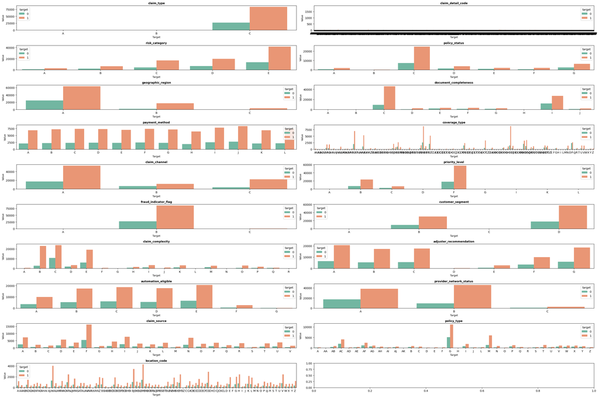

```python
cat_cols = [c for c in categorical_cols if c not in ['claim_detail_code', 'fraud_indicator_flag', 'claim_type']]
num_cols = len(categorical_cols)
num_rows = (num_cols + 1) // 2

fig, axes = plt.subplots(num_rows, 2, figsize=(30, 2*num_rows))
axes = axes.flatten()

for idx, col in enumerate(categorical_cols):
    ax = axes[idx]
    plot_data = data[['target', col]].dropna()
    sns.countplot(data=plot_data, x=col, hue='target', ax=ax, palette="Set2")
    ax.set_title(f"{col}", fontsize=10, fontweight='bold')
    ax.set_ylabel("Value", fontsize=9)
    ax.set_xlabel("Target", fontsize=9)

plt.tight_layout()
plt.show()
```

most of classes look the same always high on the target 1 and low in the target 0

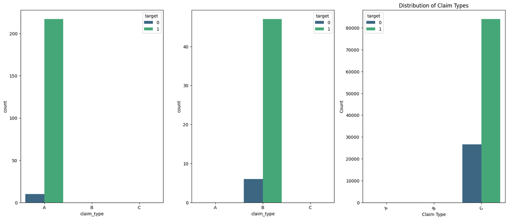

```python
fig, ax = plt.subplots(1, 3, figsize=(20, 8))
sns.countplot(
    data=data[data['claim_type'].isin(['A'])],
    x='claim_type',
    hue='target',
    palette="viridis",
    ax = ax[0]
)
sns.countplot(
    data=data[data['claim_type'].isin(['B'])],
    x='claim_type',
    hue='target',
    palette="viridis",
    ax = ax[1]
)
sns.countplot(
    data=data[data['claim_type'].isin(['C'])],
    x='claim_type',
    hue='target',
    palette="viridis",
    ax = ax[2]
)
plt.title("Distribution of Claim Types")
plt.xlabel("Claim Type")
plt.ylabel("Count")
plt.xticks(rotation=45)
plt.show()
```

The distribition looks close across B,C, but A looks like a indicator for the target

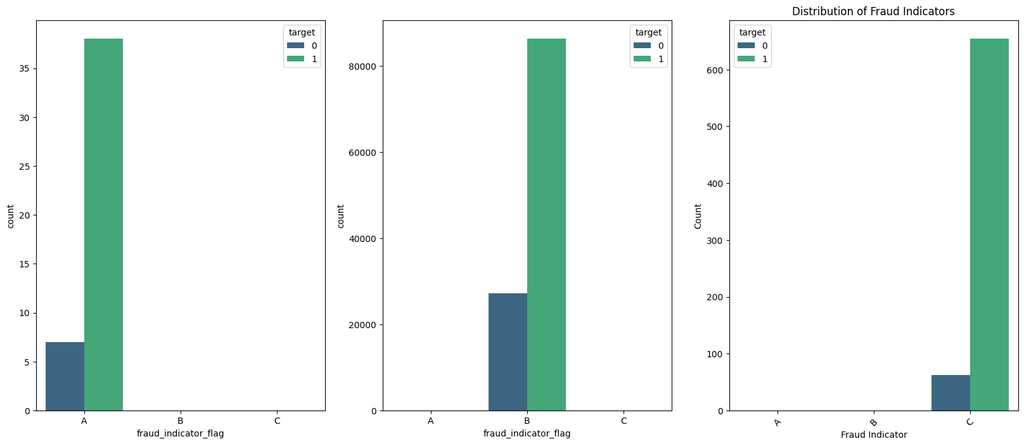

```python
fig, ax = plt.subplots(1, 3, figsize=(20, 8))
sns.countplot(
    data=data[data['fraud_indicator_flag'].isin(['A'])],
    x='fraud_indicator_flag',
    hue='target',
    palette="viridis",
    ax = ax[0]
)
sns.countplot(
    data=data[data['fraud_indicator_flag'].isin(['B'])],
    x='fraud_indicator_flag',
    hue='target',
    palette="viridis",
    ax = ax[1]
)
sns.countplot(
    data=data[data['fraud_indicator_flag'].isin(['C'])],
    x='fraud_indicator_flag',
    hue='target',
    palette="viridis",
    ax = ax[2]
)
plt.title("Distribution of Fraud Indicators")
plt.xlabel("Fraud Indicator")
plt.ylabel("Count")
plt.xticks(rotation=45)
plt.show()
```

The distribition looks close across A,B,C, so this variable could be just noise, but for the unsupervised part we will keep it

## Numerical Features Analysis

```python
data.describe(include='number').T
```

|  | count | mean | std | min | 25% | 50% | 75% | max |
| --- | --- | --- | --- | --- | --- | --- | --- | --- |
| claim_amount_ratio | 64489.0 | 1.630686 | 1.082814 | -9.996497e-07 | 0.913580 | 1.469550 | 2.136128 | 20.0 |
| risk_score | 64525.0 | 7.464411 | 2.961676 | -9.817614e-07 | 5.316428 | 7.023803 | 9.465497 | 20.0 |
| deductible_ratio | 64525.0 | 4.145097 | 1.148263 | -6.475929e-07 | 3.487398 | 4.205991 | 4.833251 | 20.0 |
| premium_payment_score | 65697.0 | 8.742359 | 2.036018 | -5.287068e-07 | 7.605918 | 8.670867 | 9.771353 | 20.0 |
| claim_reserve_amount | 64489.0 | 2.436401 | 0.599965 | -9.055091e-07 | 2.065064 | 2.412791 | 2.775285 | 20.0 |
| ... | ... | ... | ... | ... | ... | ... | ... | ... |
| expedited_processing_score | 64489.0 | 3.239542 | 1.625988 | -9.223797e-07 | 2.101900 | 2.963620 | 4.108146 | 20.0 |
| claim_quality_index | 65697.0 | 2.030373 | 1.074232 | 8.197812e-07 | 1.393830 | 1.798436 | 2.390157 | 20.0 |
| customer_value_score | 114321.0 | 0.310144 | 0.693262 | 0.000000e+00 | 0.000000 | 0.000000 | 0.000000 | 11.0 |
| regulatory_compliance_score | 64478.0 | 1.925763 | 1.264497 | -9.901257e-07 | 1.106172 | 1.560138 | 2.332425 | 20.0 |
| final_decision_confidence | 64426.0 | 1.739389 | 1.134702 | -9.999134e-07 | 1.012658 | 1.589403 | 2.261905 | 20.0 |

112 rows × 8 columns

WE notice that most of the variables have NAs around the same percentage

the data is full of outliers and most of them have max around 20 and a min around -10e-07 or 0 for some variables

there are some variables that have dicrete values which are: ['severity_index', 'communication_touchpoints', 'recovery_probability', 'customer_value_score'], we explore them

```python
weird_cols = ['severity_index', 'communication_touchpoints', 'recovery_probability', 'customer_value_score']
```

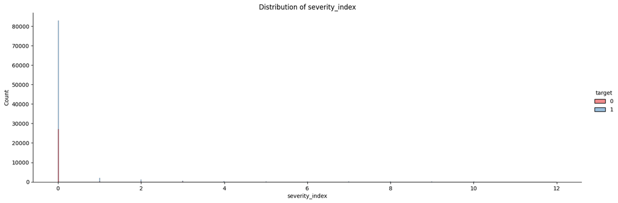

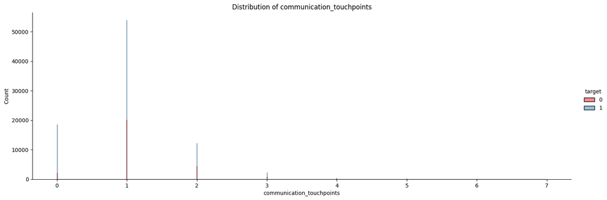

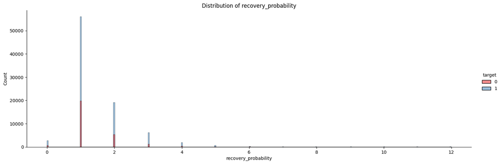

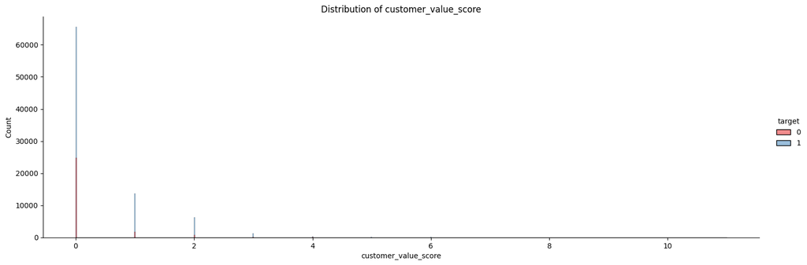

```python
for col in weird_cols:
    sns.displot(data=data, x=col, hue='target', aspect=3, palette="Set1")
    plt.title(f"Distribution of {col}")
    plt.show()
```

```python
unique_vs_target = pd.concat(
    [
        pd.crosstab(data[col], data["target"], dropna=False)
        .rename(columns=lambda x: f"target_{x}")
        .reset_index()
        .rename(columns={col: "value"})
        .assign(variable=col)
        for col in weird_cols
    ],
    ignore_index=True
)

target_cols = [c for c in unique_vs_target.columns if c.startswith("target_")]
unique_vs_target = unique_vs_target[["variable", "value"] + target_cols]
unique_vs_target["total"] = unique_vs_target[target_cols].sum(axis=1)

unique_vs_target.sort_values(["variable", "total"], ascending=[True, False], inplace=True)
unique_vs_target
```

| target | variable | value | target_0 | target_1 | total |
| --- | --- | --- | --- | --- | --- |
| 13 | communication_touchpoints | 1 | 20019 | 53811 | 73830 |
| 12 | communication_touchpoints | 0 | 2122 | 18508 | 20630 |
| 14 | communication_touchpoints | 2 | 4344 | 12069 | 16413 |
| 15 | communication_touchpoints | 3 | 684 | 2142 | 2826 |
| 16 | communication_touchpoints | 4 | 100 | 371 | 471 |
| 17 | communication_touchpoints | 5 | 27 | 72 | 99 |
| 18 | communication_touchpoints | 6 | 4 | 43 | 47 |
| 19 | communication_touchpoints | 7 | 0 | 5 | 5 |
| 33 | customer_value_score | 0 | 24740 | 65507 | 90247 |
| 34 | customer_value_score | 1 | 1690 | 13623 | 15313 |
| 35 | customer_value_score | 2 | 714 | 6175 | 6889 |
| 36 | customer_value_score | 3 | 106 | 1267 | 1373 |
| 37 | customer_value_score | 4 | 33 | 324 | 357 |
| 38 | customer_value_score | 5 | 13 | 70 | 83 |
| 39 | customer_value_score | 6 | 2 | 43 | 45 |
| 42 | customer_value_score | 11 | 1 | 7 | 8 |
| 40 | customer_value_score | 7 | 0 | 3 | 3 |
| 41 | customer_value_score | 8 | 1 | 2 | 3 |
| 21 | recovery_probability | 1 | 19807 | 55960 | 75767 |
| 22 | recovery_probability | 2 | 5255 | 19086 | 24341 |
| 23 | recovery_probability | 3 | 1161 | 6108 | 7269 |
| 20 | recovery_probability | 0 | 664 | 2691 | 3355 |
| 24 | recovery_probability | 4 | 287 | 1934 | 2221 |
| 25 | recovery_probability | 5 | 80 | 605 | 685 |
| 26 | recovery_probability | 6 | 23 | 265 | 288 |
| 27 | recovery_probability | 7 | 8 | 123 | 131 |
| 28 | recovery_probability | 8 | 2 | 87 | 89 |
| 29 | recovery_probability | 9 | 2 | 69 | 71 |
| 30 | recovery_probability | 10 | 0 | 56 | 56 |
| 32 | recovery_probability | 12 | 8 | 24 | 32 |
| 31 | recovery_probability | 11 | 3 | 13 | 16 |
| 0 | severity_index | 0 | 26948 | 82776 | 109724 |
| 1 | severity_index | 1 | 189 | 1954 | 2143 |
| 2 | severity_index | 2 | 90 | 1108 | 1198 |
| 3 | severity_index | 3 | 29 | 505 | 534 |
| 4 | severity_index | 4 | 14 | 242 | 256 |
| 5 | severity_index | 5 | 13 | 140 | 153 |
| 7 | severity_index | 7 | 5 | 80 | 85 |
| 6 | severity_index | 6 | 2 | 67 | 69 |
| 8 | severity_index | 8 | 0 | 61 | 61 |
| 10 | severity_index | 10 | 9 | 38 | 47 |
| 9 | severity_index | 9 | 1 | 37 | 38 |
| 11 | severity_index | 12 | 0 | 13 | 13 |

Usually the outliers in finance/insurance are indicators of the target and meaninfull, but we see they follow the same distribition across the target as the rest of values for these variables

### Correlation Analysis

```
Statistics for top 60 features correlated with target:
count    60.000000
mean      0.018936
std       0.060886
min      -0.093709
25%      -0.033705
50%       0.030945
75%       0.048545
max       0.241683
Name: target_num, dtype: float64
Top 60 features correlated with target:
```

|  | correlation |
| --- | --- |
| prior_denial_indicator | 0.241683 |
| claim_processing_days | 0.148680 |
| customer_value_score | 0.142141 |
| coverage_limit | 0.130670 |
| policy_premium_annual | 0.095884 |
| communication_touchpoints | -0.093709 |
| cross_sell_index | 0.075786 |
| recovery_probability | 0.075241 |
| previous_claims_value | 0.067634 |
| severity_index | 0.061863 |
| deductible_ratio | 0.059842 |
| optional_coverage_count | -0.058578 |
| claim_submission_completeness | -0.055940 |
| reinsurance_amount | -0.055493 |
| policy_renewal_months | 0.054710 |
| specialist_referrals | 0.054226 |
| image_quality_score | 0.051708 |
| adjustments_count | 0.050931 |
| diagnosis_complexity_score | 0.050835 |
| regional_fraud_index | -0.050820 |
| policy_compliance_score | -0.049183 |
| policy_riders_count | 0.047781 |
| claim_complexity_score | 0.047620 |
| settlement_confidence_score | 0.046616 |
| regulatory_compliance_score | -0.046252 |
| policy_age_days | -0.046213 |
| documents_submitted_count | -0.045500 |
| regional_cost_index | -0.045349 |
| liability_percentage | 0.045078 |
| online_activity_score | -0.044467 |
| income_bracket_index | 0.044028 |
| loss_ratio_history | -0.040873 |
| product_age_years | -0.040860 |
| extensions_requested | 0.040021 |
| distance_to_provider | -0.040008 |
| settlement_acceptance_probability | -0.036793 |
| risk_score | 0.036568 |
| claim_quality_index | 0.034045 |
| policy_value_score | 0.033370 |
| system_latency_score | 0.032925 |
| policy_discount_percentage | 0.032899 |
| estimated_settlement_amount | -0.032675 |
| api_response_quality | 0.032565 |
| fraud_probability_score | -0.032436 |
| line_items_count | 0.032393 |
| witnesses_count | -0.032392 |
| v32 | -0.032277 |
| household_size | 0.031741 |
| zip_code_risk_score | -0.031728 |
| coverage_breadth_score | 0.031114 |
| incurred_loss_estimate | -0.031080 |
| medical_providers_count | 0.030776 |
| claim_reserve_amount | 0.030610 |
| customer_tenure_years | 0.030004 |
| predictive_risk_score | 0.028870 |
| incident_to_claim_hours | 0.028798 |
| anti_fraud_score | -0.028626 |
| customer_loyalty_score | 0.028478 |
| regional_claim_frequency_index | -0.028250 |
| final_decision_confidence | 0.027538 |

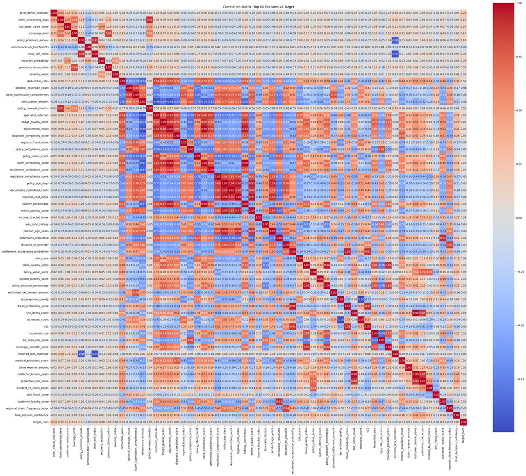

```python
target_num = pd.to_numeric(data["target"], errors="coerce")

corr_df = data[numeric_cols].copy()
corr_df["target_num"] = target_num

target_corr = (
    corr_df.corr(numeric_only=True)["target_num"]
    .drop("target_num")
    .sort_values(key=lambda s: s.abs(), ascending=False)
)

top60_features = target_corr.head(60)
stat_top60 = top60_features.describe()
print("Statistics for top 60 features correlated with target:")
print(stat_top60)

print("Top 60 features correlated with target:")
display(top60_features.to_frame(name="correlation"))

top_cols = top60_features.index.tolist() + ["target_num"]
corr_matrix = corr_df[top_cols].corr(numeric_only=True)

plt.figure(figsize=(30, 25))
sns.heatmap(corr_matrix, cmap="coolwarm",fmt=".2f", center=0, annot=True, square=True)
plt.title("Correlation Matrix: Top 60 Features vs Target")
plt.tight_layout()
plt.show()
```

We observe very weak correlation with the target (mean = 0.0189, min = -0.0937, median = 0.0309, max = 0.2417), indicating limited linear relationship between individual features and the target variable. This suggests that predictive information is likely distributed across feature interactions rather than single variables. Strong multicollinearity is also present, including near-perfect correlations, indicating redundancy.

```python
num_df = data.select_dtypes(include=[np.number]).drop(columns=['target'], errors='ignore')

corr_matrix = num_df.corr(numeric_only=True)

# Build unique variable pairs (no self-pairs, no duplicated reversed pairs)
mask_upper = np.triu(np.ones(corr_matrix.shape, dtype=bool), k=1)
corr_pairs = (
    corr_matrix.where(mask_upper)
    .stack()
    .reset_index()
)
corr_pairs.columns = ['feature_1', 'feature_2', 'correlation']
corr_pairs['abs_correlation'] = corr_pairs['correlation'].abs()
corr_pairs = corr_pairs.sort_values('abs_correlation', ascending=False).reset_index(drop=True)

# Show sorted correlations between variables
display(corr_pairs)

# Remove features with correlation > 0.98 (absolute), keeping the first feature
upper_tri = corr_matrix.where(np.triu(np.ones(corr_matrix.shape), k=1).astype(bool))
to_drop = [col for col in upper_tri.columns if (upper_tri[col].abs() > 0.98).any()]

data.drop(columns=to_drop, inplace=True, errors='ignore')

print(f"Number of removed features (>0.98 absolute correlation): {len(to_drop)}")
print("Removed features:")
print(to_drop if to_drop else "None")
```

|  | feature_1 | feature_2 | correlation | abs_correlation |
| --- | --- | --- | --- | --- |
| 0 | witnesses_count | api_response_quality | -0.997665 | 0.997665 |
| 1 | network_discount_rate | renewal_count | -0.993691 | 0.993691 |
| 2 | claim_complexity_score | liability_percentage | 0.992671 | 0.992671 |
| 3 | claim_validity_score | external_verifications_count | 0.991609 | 0.991609 |
| 4 | claim_complexity_score | adjustments_count | 0.982626 | 0.982626 |
| ... | ... | ... | ... | ... |
| 12539 | final_decision_confidence | expedited_processing_score | NaN | NaN |
| 12540 | final_decision_confidence | claim_quality_index | NaN | NaN |
| 12541 | final_decision_confidence | customer_value_score | NaN | NaN |
| 12542 | final_decision_confidence | regulatory_compliance_score | NaN | NaN |
| 12543 | final_decision_confidence | final_decision_confidence | NaN | NaN |

12544 rows × 4 columns

```
Number of removed features (>0.98 absolute correlation): 8
Removed features:
['claim_validity_score', 'line_items_count', 'external_verifications_count', 'adjustments_count', 'liability_percentage', 'api_response_quality', 'specialist_referrals', 'renewal_count']
```

Since correlation-based feature removal is unstable (removing correlated variables leads to new correlations among remaining features), only extreme cases (8 features with |r| > 0.98) were removed in a single pass.

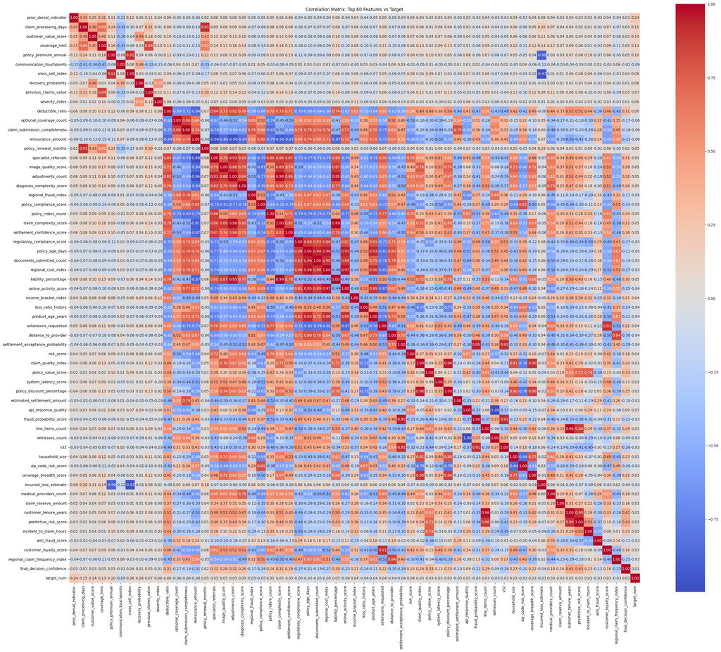

```python
target_corr = (
    corr_df.corr(numeric_only=True)["target_num"]
    .drop("target_num")
    .sort_values(key=lambda s: s.abs(), ascending=False)
)

top60_features = target_corr.head(60)

top_cols = top60_features.index.tolist() + ["target_num"]
corr_matrix = corr_df[top_cols].corr(numeric_only=True)

plt.figure(figsize=(30, 25))
sns.heatmap(corr_matrix, cmap="coolwarm",fmt=".2f", center=0, annot=True, square=True)
plt.title("Correlation Matrix: Top 60 Features vs Target")
plt.tight_layout()
plt.show()
```

# Preprocessing

## Handling missing values

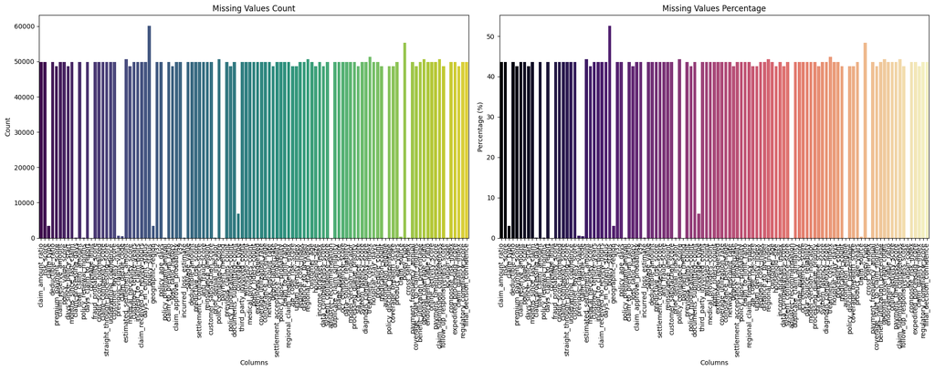

```python
null_counts = data.isnull().sum()
null_counts = null_counts[null_counts > 0]
null_percent = (null_counts / len(data)) * 100

fig, axes = plt.subplots(1, 2, figsize=(20, 8))

sns.barplot(x=null_counts.index, y=null_counts.values, ax=axes[0], palette="viridis")
axes[0].set_title("Missing Values Count")
axes[0].set_xlabel("Columns")
axes[0].set_ylabel("Count")
axes[0].tick_params(axis='x', rotation=90)

sns.barplot(x=null_percent.index, y=null_percent.values, ax=axes[1], palette="magma")
axes[1].set_title("Missing Values Percentage")
axes[1].set_xlabel("Columns")
axes[1].set_ylabel("Percentage (%)")
axes[1].tick_params(axis='x', rotation=90)

plt.tight_layout()
plt.show()
```

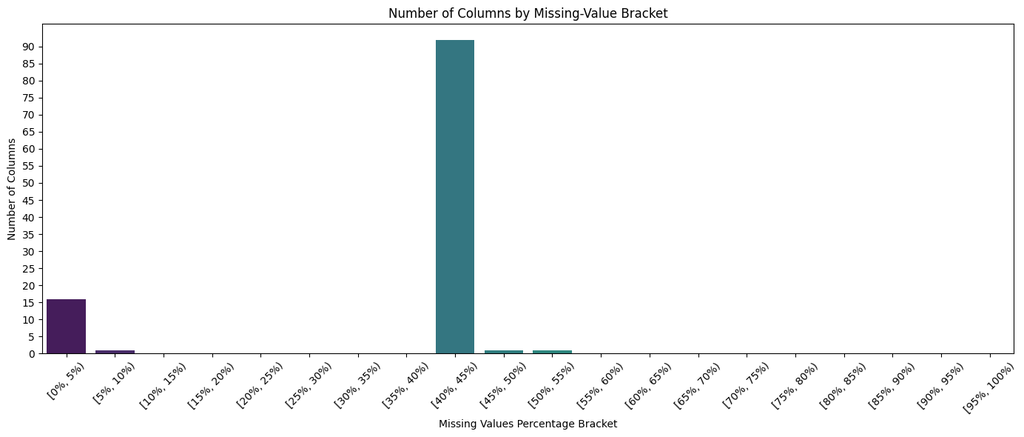

```python
missing_pct = data.isnull().mean().mul(100)

# exclude columns with 0 missing values
missing_pct_nonzero = missing_pct[missing_pct > 0]

bins = np.arange(0, 101, 5)
labels = [f'[{bins[i]}%, {bins[i+1]}%)' for i in range(len(bins) - 1)]

pct_group = pd.cut(
    missing_pct_nonzero.clip(upper=99.999999),
    bins=bins,
    labels=labels,
    right=False,
    include_lowest=True
)

cols_per_group = pct_group.value_counts().reindex(labels, fill_value=0)

plt.figure(figsize=(14, 6))
sns.barplot(x=cols_per_group.index.astype(str), y=cols_per_group.values, palette="viridis")
plt.xlabel("Missing Values Percentage Bracket")
plt.ylabel("Number of Columns")
plt.title("Number of Columns by Missing-Value Bracket")
plt.xticks(rotation=45)
plt.yticks(range(0, max(cols_per_group.values) + 1, 5))
plt.tight_layout()
plt.show()
```

```python
missing_pct = data.isnull().mean().mul(100)
cols_0to5 = missing_pct[
    (missing_pct > 0) & (missing_pct <= 5)
].index.tolist()
cols_5to10 = missing_pct[
    (missing_pct > 5) & (missing_pct <= 10)
].index.tolist()
cols_40to45 = missing_pct[
    (missing_pct > 40) & (missing_pct <= 45)
].index.tolist()
cols_45to50 = missing_pct[
    (missing_pct > 45) & (missing_pct <= 50)
].index.tolist()
cols_50to55 = missing_pct[
    (missing_pct > 50) & (missing_pct <= 55)
].index.tolist()

len(cols_0to5), len(cols_5to10), len(cols_40to45), len(cols_45to50), len(cols_50to55)
```

```
(16, 1, 92, 1, 1)
```

there are 2 varibles that have about 50% of NAs, we explore them first to see if this missingness is not random and valuable

```python
cols_50to55,cols_45to50
```

```
(['policy_status'], ['policy_type'])
```

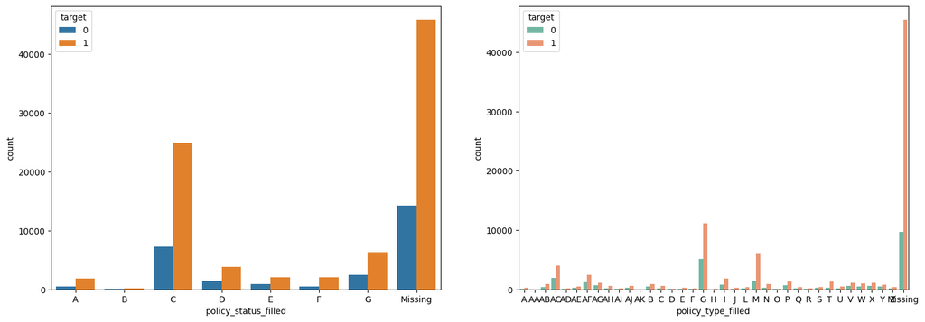

```python
data['policy_status_filled'] = data['policy_status'].cat.add_categories(['Missing']).fillna('Missing')
data['policy_type_filled'] = data['policy_type'].cat.add_categories(['Missing']).fillna('Missing')
fig, axes = plt.subplots(1, 2, figsize=(18, 6))
sns.countplot(x='policy_status_filled', data=data,hue= 'target', ax=axes[0])
sns.countplot(x='policy_type_filled', data=data,hue= 'target', palette="Set2", ax=axes[1])
plt.show()
```

```python
data['policy_type_filled'].value_counts()
```

```
policy_type_filled
Missing    55304
G          16252
M           7374
AC          5956
AF          3568
I           2605
P           1975
AG          1712
V           1673
X           1635
T           1608
W           1497
B           1358
Y           1282
AB          1273
N           1186
AJ           872
AH           797
C            707
AE           680
S            614
U            612
Q            594
L            477
Z            453
A            334
E            324
J            322
AI           313
AD           265
F            233
R            181
D            142
O            100
H             41
AA             1
AK             1
Name: count, dtype: int64
```

```python
pd.crosstab(data['policy_status_filled'], data['target'], normalize='index')
```

| target policy_status_filled | 0 | 1 |
| --- | --- | --- |
| A | 0.208387 | 0.791613 |
| B | 0.126829 | 0.873171 |
| C | 0.225527 | 0.774473 |
| D | 0.278086 | 0.721914 |
| E | 0.310124 | 0.689876 |
| F | 0.193511 | 0.806489 |
| G | 0.278414 | 0.721586 |
| Missing | 0.236716 | 0.763284 |

```python
pd.crosstab(data['policy_type_filled'], data['target'], normalize='index')
```

| target policy_type_filled | 0 | 1 |
| --- | --- | --- |
| A | 0.293413 | 0.706587 |
| AA | 0.000000 | 1.000000 |
| AB | 0.318146 | 0.681854 |
| AC | 0.327401 | 0.672599 |
| AD | 0.245283 | 0.754717 |
| AE | 0.357353 | 0.642647 |
| AF | 0.322870 | 0.677130 |
| AG | 0.382593 | 0.617407 |
| AH | 0.268507 | 0.731493 |
| AI | 0.348243 | 0.651757 |
| AJ | 0.347477 | 0.652523 |
| AK | 0.000000 | 1.000000 |
| B | 0.313697 | 0.686303 |
| C | 0.196605 | 0.803395 |
| D | 0.295775 | 0.704225 |
| E | 0.212963 | 0.787037 |
| F | 0.085837 | 0.914163 |
| G | 0.314669 | 0.685331 |
| H | 0.146341 | 0.853659 |
| I | 0.294818 | 0.705182 |
| J | 0.270186 | 0.729814 |
| L | 0.322851 | 0.677149 |
| M | 0.187280 | 0.812720 |
| N | 0.218381 | 0.781619 |
| O | 0.250000 | 0.750000 |
| P | 0.342278 | 0.657722 |
| Q | 0.301347 | 0.698653 |
| R | 0.259669 | 0.740331 |
| S | 0.418567 | 0.581433 |
| T | 0.172886 | 0.827114 |
| U | 0.287582 | 0.712418 |
| V | 0.373580 | 0.626420 |
| W | 0.312625 | 0.687375 |
| X | 0.338838 | 0.661162 |
| Y | 0.382215 | 0.617785 |
| Z | 0.278146 | 0.721854 |
| Missing | 0.176117 | 0.823883 |

in the variable "policy_type", there are classes with perfect distribition(0,1) which are AA,AK, at the first glance they seem very valuable but after cheking their effective : AK:1, AA:1, they only have 1 observation

the distrition of target is almost the same across different classes including the missing values for the variables "policy_type" and "policy_status", so this missingness or this variable does not give much value for predicting the target + high NAs(~50%) so we drop them

```python
data = data.drop([cols_45to50[0], cols_50to55[0],'policy_status_filled','policy_type_filled'], axis=1)
data.info()
```

```
<class 'pandas.DataFrame'>
RangeIndex: 114321 entries, 0 to 114320
Columns: 122 entries, target to final_decision_confidence
dtypes: category(18), float32(100), int8(4)
memory usage: 46.8 MB
```

We do the same for the cols_5to10

```python
cols_5to10,data[cols_5to10[0]].unique()
```

```
(['coverage_type'],
 ['DI', 'DY', 'AS', 'BW', NaN, ..., 'BO', 'DD', 'BT', 'D', 'DC']
 Length: 123
 Categories (122, str): ['A', 'AA', 'AB', 'AC', ..., 'W', 'X', 'Y', 'Z'])
```

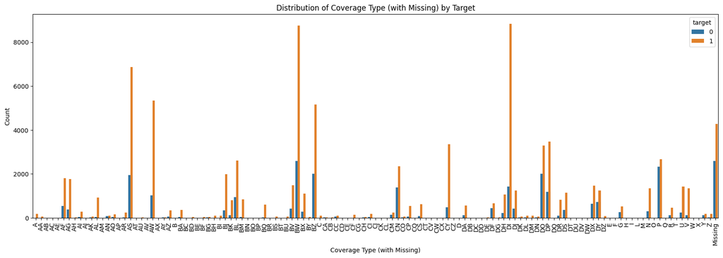

```python
data['coverage_type'] = data['coverage_type'].cat.add_categories(['Missing']).fillna('Missing')
plt.figure(figsize=(20,6))
sns.countplot(x='coverage_type', data=data, hue='target')
plt.xlabel("Coverage Type (with Missing)")
plt.ylabel("Count")
plt.title("Distribution of Coverage Type (with Missing) by Target")
plt.xticks(rotation=90)
plt.show()
```

The distribition differs a bit across diffrent classes especially in the missing class and 'P' class, so this varibale could give info so we keep it and filled the NAs as a class

A rule of thumb is to delete row of NAs if <5%

```python
data.dropna(subset=cols_0to5, inplace=True)
data.info()
```

```
<class 'pandas.DataFrame'>
Index: 109537 entries, 0 to 114320
Columns: 122 entries, target to final_decision_confidence
dtypes: category(18), float32(100), int8(4)
memory usage: 45.7 MB
```

```python
data[cols_40to45].dtypes
```

```
claim_amount_ratio             float32
risk_score                     float32
deductible_ratio               float32
premium_payment_score          float32
claim_reserve_amount           float32
                                ...
composite_risk_index           float32
expedited_processing_score     float32
claim_quality_index            float32
regulatory_compliance_score    float32
final_decision_confidence      float32
Length: 92, dtype: object
```

all the cols_40to45 are numerical variables

```python
data[cols_40to45]
```

|  | claim_amount_ratio | risk_score | deductible_ratio | premium_payment_score | claim_reserve_amount | policy_value_score | days_since_policy_start | months_since_last_claim | total_claim_amount | days_claim_to_report | ... | endorsement_value_ratio | online_activity_score | payment_timeliness_score | claim_submission_completeness | follow_up_responsiveness_score | composite_risk_index | expedited_processing_score | claim_quality_index | regulatory_compliance_score | final_decision_confidence |
| --- | --- | --- | --- | --- | --- | --- | --- | --- | --- | --- | --- | --- | --- | --- | --- | --- | --- | --- | --- | --- | --- |
| 0 | 1.335739 | 8.727474 | 3.921026 | 7.915266 | 2.599278 | 3.176895 | 0.012941 | 9.999999 | 16.434109 | 2.866829 | ... | 1.059603 | 0.803572 | 8.000000 | 1.989780 | 0.035754 | 1.804126 | 3.113719 | 2.024285 | 0.636365 | 2.857144 |
| 1 | NaN | NaN | NaN | 9.191265 | NaN | NaN | 2.301630 | NaN | NaN | NaN | ... | NaN | NaN | NaN | NaN | 0.598896 | NaN | NaN | 1.957825 | NaN | NaN |
| 2 | 0.943877 | 5.310079 | 4.410969 | 5.326159 | 3.979592 | 3.928571 | 0.019645 | 12.666667 | 14.756098 | 2.505589 | ... | 2.138728 | 2.238806 | 9.333333 | 2.477596 | 0.013452 | 1.773709 | 3.922193 | 1.120468 | 0.883118 | 1.176471 |
| 3 | 0.797415 | 8.304757 | 4.225930 | 11.627439 | 2.097700 | 1.987549 | 0.171947 | 8.965516 | 16.347483 | 3.903302 | ... | 1.166281 | 1.956521 | 7.018256 | 1.812795 | 0.002267 | 1.415230 | 2.954381 | 1.990847 | 1.677108 | 1.034483 |
| 4 | NaN | NaN | NaN | NaN | NaN | NaN | NaN | NaN | NaN | NaN | ... | NaN | NaN | NaN | NaN | NaN | NaN | NaN | NaN | NaN | NaN |
| ... | ... | ... | ... | ... | ... | ... | ... | ... | ... | ... | ... | ... | ... | ... | ... | ... | ... | ... | ... | ... | ... |
| 114316 | NaN | NaN | NaN | NaN | NaN | NaN | NaN | NaN | NaN | NaN | ... | NaN | NaN | NaN | NaN | NaN | NaN | NaN | NaN | NaN | NaN |
| 114317 | NaN | NaN | NaN | NaN | NaN | NaN | NaN | NaN | NaN | NaN | ... | NaN | NaN | NaN | NaN | NaN | NaN | NaN | NaN | NaN | NaN |
| 114318 | NaN | NaN | NaN | 10.069277 | NaN | NaN | 0.323324 | NaN | NaN | NaN | ... | NaN | NaN | NaN | NaN | 0.156764 | NaN | NaN | 2.417606 | NaN | NaN |
| 114319 | NaN | NaN | NaN | 10.106144 | NaN | NaN | 0.309226 | NaN | NaN | NaN | ... | NaN | NaN | NaN | NaN | 0.490658 | NaN | NaN | 3.526650 | NaN | NaN |
| 114320 | 1.619763 | 7.932978 | 4.640085 | 8.473141 | 2.351470 | 2.826766 | 3.479754 | 9.629630 | 14.959786 | 4.195219 | ... | 0.737218 | 4.016948 | 7.936508 | 2.944285 | 3.135205 | 1.943149 | 4.385553 | 1.604493 | 1.787610 | 1.386138 |

109537 rows × 92 columns

[output not shown]

[output cut: 405 more lines]

[output not shown]

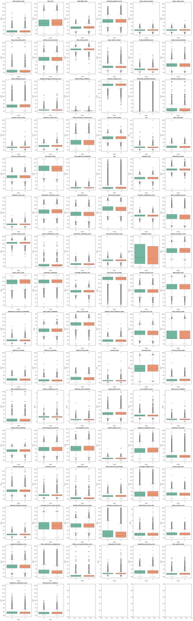

```python
num_cols = len(cols_40to45)
num_rows = (num_cols + 5) // 6

fig, axes = plt.subplots(num_rows, 6, figsize=(25, 5*num_rows))
axes = axes.flatten()

for idx, col in enumerate(cols_40to45):
    ax = axes[idx]
    plot_data = data[['target', col]].dropna()
    sns.boxplot(data=plot_data, x='target', y=col, ax=ax, palette="Set2")
    ax.set_title(f"{col}", fontsize=10, fontweight='bold')
    ax.set_ylabel("Value", fontsize=9)
    ax.set_xlabel("Target", fontsize=9)

plt.tight_layout()
plt.show()
```

the distribition is almost identical across the target for all these varibales and full of outliers which could cause problems in some unsupervised techniques(they depend in distance).

but we keep the variables because they are a lot and could be useful non linear interactions between them that are not visible so we impute them.

```python
rf = RandomForestRegressor(n_estimators=10, max_depth=5, n_jobs=-2, random_state=42)
imputer = IterativeImputer(estimator=rf, max_iter=2, n_nearest_features=15, skip_complete=True, random_state=42, sample_posterior=False)

imputed = imputer.fit_transform(data[cols_40to45])
```

We will not use a single value like mean or median due to the large proportion of NAs, we will use modeling via bagging(random forest) instead of KNN because it rely on distance and this is a very high dimensional data, so it will be computional expensive also for the high dimensional curse(distance lose its meaning)

```python
data[cols_40to45] = pd.DataFrame(imputed, columns=cols_40to45, index=data.index)
data.head()
```

|  | target | claim_amount_ratio | risk_score | claim_type | deductible_ratio | premium_payment_score | claim_reserve_amount | policy_value_score | days_since_policy_start | months_since_last_claim | ... | payment_timeliness_score | claim_submission_completeness | follow_up_responsiveness_score | location_code | composite_risk_index | expedited_processing_score | claim_quality_index | customer_value_score | regulatory_compliance_score | final_decision_confidence |
| --- | --- | --- | --- | --- | --- | --- | --- | --- | --- | --- | --- | --- | --- | --- | --- | --- | --- | --- | --- | --- | --- |
| 0 | 1 | 1.335739 | 8.727474 | C | 3.921026 | 7.915266 | 2.599278 | 3.176895 | 0.012941 | 9.999999 | ... | 8.000000 | 1.989780 | 0.035754 | AU | 1.804126 | 3.113719 | 2.024285 | 0 | 0.636365 | 2.857144 |
| 1 | 1 | 1.704065 | 6.440571 | C | 3.987185 | 9.191265 | 2.445379 | 2.381780 | 2.301630 | 9.052274 | ... | 6.689778 | 3.472039 | 0.598896 | AF | 1.542972 | 3.305576 | 1.957825 | 0 | 1.785516 | 1.670417 |
| 2 | 1 | 0.943877 | 5.310079 | C | 4.410969 | 5.326159 | 3.979592 | 3.928571 | 0.019645 | 12.666667 | ... | 9.333333 | 2.477596 | 0.013452 | AE | 1.773709 | 3.922193 | 1.120468 | 2 | 0.883118 | 1.176471 |
| 3 | 1 | 0.797415 | 8.304757 | C | 4.225930 | 11.627439 | 2.097700 | 1.987549 | 0.171947 | 8.965516 | ... | 7.018256 | 1.812795 | 0.002267 | CJ | 1.415230 | 2.954381 | 1.990847 | 1 | 1.677108 | 1.034483 |
| 4 | 1 | 1.704065 | 6.440571 | C | 3.987185 | 9.123690 | 2.445379 | 2.381780 | 1.195738 | 9.052274 | ... | 6.840937 | 3.472039 | 0.966108 | Z | 1.542972 | 3.305576 | 1.605921 | 0 | 1.785516 | 1.670417 |

5 rows × 122 columns

```python
data.isnull().sum().sort_values(ascending=False)
```

```
target                         0
claim_amount_ratio             0
risk_score                     0
claim_type                     0
deductible_ratio               0
                              ..
expedited_processing_score     0
claim_quality_index            0
customer_value_score           0
regulatory_compliance_score    0
final_decision_confidence      0
Length: 122, dtype: int64
```

Now we do not have any missing values

```python
mi = mutual_info_classif(data[cols_40to45], data['target'])
MI = pd.DataFrame(dict(zip(cols_40to45, mi)), index=['Mutual Information']).T.sort_values(by='Mutual Information', ascending=False)
MI
```

|  | Mutual Information |
| --- | --- |
| risk_score | 0.015911 |
| policy_value_score | 0.015543 |
| days_claim_to_report | 0.015533 |
| deductible_amount | 0.015335 |
| composite_risk_index | 0.015222 |
| ... | ... |
| coverage_breadth_score | 0.005372 |
| days_since_policy_start | 0.004267 |
| urban_density_index | 0.003446 |
| estimated_settlement_amount | 0.003154 |
| final_decision_confidence | 0.002569 |

92 rows × 1 columns

Mutual information is not bounded to 1, but in practice:

~0.00 → no relationship ~0.01–0.02 → extremely weak signal ~0.05+ → weak but usable ~0.1+ → decent predictive signal ~0.2+ → strong signal

So:

0.016 max = very weak dependence between individual features and target this is likely because Signal is distributed, not isolated

## Handling Outliers

First we identify outliers using boxplots

[output not shown]

[output cut: 465 more lines]

[output not shown]

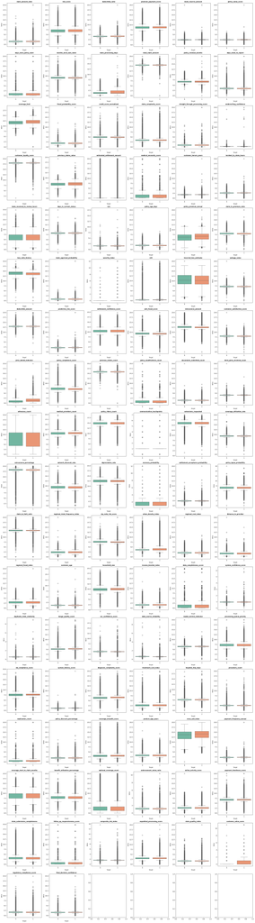

```python
numeric_cols = data.select_dtypes(include=[np.number]).columns.tolist()
num_cols = len(numeric_cols)
num_rows = (num_cols + 5) // 6

fig, axes = plt.subplots(num_rows, 6, figsize=(25, 5*num_rows))
axes = axes.flatten()

for idx, col in enumerate(numeric_cols):
    ax = axes[idx]
    plot_data = data[['target', col]].dropna()
    sns.boxplot(data=plot_data, x='target', y=col, ax=ax, palette="Set2")
    ax.set_title(f"{col}", fontsize=10, fontweight='bold')
    ax.set_ylabel("Value", fontsize=9)
    ax.set_xlabel("Target", fontsize=9)

plt.tight_layout()
plt.show()
```

We notice that the ouitiers are present in all the variables and have the Same distribution across target classes

They look like noise,It does not seem like there is a pattern for them,but we see their histograms to get more informations

[output not shown]

[output cut: 153 more lines]

[output not shown]

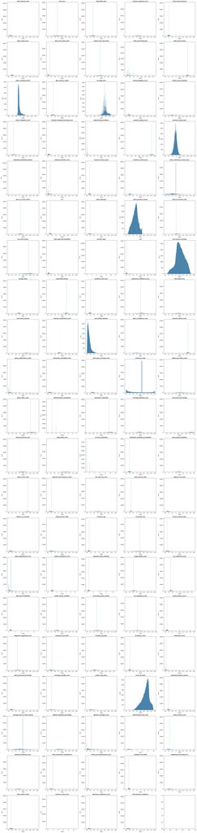

```python
num_rows = (num_cols + 4) // 5

fig, axes = plt.subplots(num_rows, 5, figsize=(25, 5*num_rows))
axes = axes.flatten()

for idx, col in enumerate(numeric_cols):
    ax = axes[idx]
    plot_data = data[['target', col]].dropna()
    sns.histplot(data=plot_data, x=col, ax=ax, palette="blues", edgecolor='black')
    ax.set_title(f"{col}", fontsize=10, fontweight='bold')
    ax.set_ylabel("Value", fontsize=9)
    ax.set_xlabel("Target", fontsize=9)

plt.tight_layout()
plt.show()
```

Almost all the numeric variables have the same shape, a flat line then a spike reaching almost half the data the a flat line again, that is why the data is full of outliers.

These outliers could form clusters later, so we keep them and use RobustScaler to scale the variables along with standard scaler

```python
data_scaled_robust = data.copy()
data_scaled_standard = data.copy()

scaler_robust = RobustScaler()
scaler_standard = StandardScaler()

data_scaled_robust[numeric_cols] = scaler_robust.fit_transform(data_scaled_robust[numeric_cols])
data_scaled_standard[numeric_cols] = scaler_standard.fit_transform(data_scaled_standard[numeric_cols])
data_scaled_robust.head()
```

|  | target | claim_amount_ratio | risk_score | claim_type | deductible_ratio | premium_payment_score | claim_reserve_amount | policy_value_score | days_since_policy_start | months_since_last_claim | ... | payment_timeliness_score | claim_submission_completeness | follow_up_responsiveness_score | location_code | composite_risk_index | expedited_processing_score | claim_quality_index | customer_value_score | regulatory_compliance_score | final_decision_confidence |
| --- | --- | --- | --- | --- | --- | --- | --- | --- | --- | --- | --- | --- | --- | --- | --- | --- | --- | --- | --- | --- | --- |
| 0 | 1 | -1.057792 | 2.030596 | C | -0.196623 | -1.652423 | 1.100648 | 5.529372 | -1.274305 | 2.132486 | ... | 2.266230 | -1.646367 | -1.056510 | AU | 2.222064 | -0.366577 | 1.459951 | 0.0 | -3.554666 | 5.006877 |
| 1 | 1 | 0.000000 | 0.000000 | C | 0.000000 | 0.092404 | 0.000000 | 0.000000 | 1.191451 | 0.000000 | ... | -0.295550 | 0.000000 | -0.417006 | AF | 0.000000 | 0.000000 | 1.228027 | 0.0 | 0.000000 | 0.000000 |
| 2 | 1 | -2.183178 | -1.003791 | C | 1.259462 | -5.192819 | 10.972333 | 10.756666 | -1.267083 | 8.132782 | ... | 4.873198 | -1.104543 | -1.081835 | AE | 1.963260 | 1.178159 | -1.694068 | 2.0 | -2.791385 | -2.083986 |
| 3 | 1 | -2.603802 | 1.655256 | C | 0.709535 | 3.423676 | -2.486517 | -2.741559 | -1.102998 | -0.195214 | ... | 0.346699 | -1.842947 | -1.094537 | CJ | -1.086912 | -0.671021 | 1.343262 | 1.0 | -0.335339 | -2.683045 |
| 4 | 1 | 0.000000 | 0.000000 | C | 0.000000 | 0.000000 | 0.000000 | 0.000000 | 0.000000 | 0.000000 | ... | 0.000000 | 0.000000 | 0.000000 | Z | 0.000000 | 0.000000 | 0.000000 | 0.0 | 0.000000 | 0.000000 |

5 rows × 122 columns

# Dimensionality Reduction

First we will use PCA, because from our previous analysis the features are highly correlated

## PCA

```python
X = data_scaled_robust[numeric_cols].copy()
X2 = data_scaled_standard[numeric_cols].copy()

pca_full = PCA()
pca_full2 = PCA()
X_pca_full = pca_full.fit_transform(X)
X2_pca_full = pca_full2.fit_transform(X2)

explained_var_ratio = pca_full.explained_variance_ratio_
explained_var_ratio2 = pca_full2.explained_variance_ratio_

explained_var = pca_full.explained_variance_
explained_var2 = pca_full2.explained_variance_

cum_explained = np.cumsum(explained_var_ratio)
cum_explained2 = np.cumsum(explained_var_ratio2)

# Summary table
pca_summary = pd.DataFrame({
    "PC": [f"PC{i+1}" for i in range(len(explained_var_ratio))],
    "Eigenvalue": explained_var,
    "Explained_Variance_Ratio": explained_var_ratio,
    "Cumulative_Explained_Variance": cum_explained
})

pca2_summary = pd.DataFrame({
    "PC": [f"PC{i+1}" for i in range(len(explained_var_ratio2))],
    "Eigenvalue": explained_var2,
    "Explained_Variance_Ratio": explained_var_ratio2,
    "Cumulative_Explained_Variance": cum_explained2
})

print(f"Original shape: {X.shape}")
print(f"Total components: {X.shape[1]}")
print("\nPCA Summary robust + data:")
display(pca_summary)
print("\nPCA Summary standard + data:")
display(pca2_summary)
```

```
Original shape: (109537, 104)
Total components: 104

PCA Summary robust + data:
```

|  | PC | Eigenvalue | Explained_Variance_Ratio | Cumulative_Explained_Variance |
| --- | --- | --- | --- | --- |
| 0 | PC1 | 2.991135e+04 | 9.780629e-01 | 0.978063 |
| 1 | PC2 | 1.454085e+02 | 4.754672e-03 | 0.982818 |
| 2 | PC3 | 1.238728e+02 | 4.050482e-03 | 0.986868 |
| 3 | PC4 | 6.480271e+01 | 2.118966e-03 | 0.988987 |
| 4 | PC5 | 5.408619e+01 | 1.768549e-03 | 0.990755 |
| ... | ... | ... | ... | ... |
| 99 | PC100 | 1.475694e-04 | 4.825330e-09 | 1.000000 |
| 100 | PC101 | 1.185842e-04 | 3.877553e-09 | 1.000000 |
| 101 | PC102 | 2.473087e-07 | 8.086679e-12 | 1.000000 |
| 102 | PC103 | 4.485523e-09 | 1.466709e-13 | 1.000000 |
| 103 | PC104 | 0.000000e+00 | 0.000000e+00 | 1.000000 |

104 rows × 4 columns

```
PCA Summary standard + data:
```

|  | PC | Eigenvalue | Explained_Variance_Ratio | Cumulative_Explained_Variance |
| --- | --- | --- | --- | --- |
| 0 | PC1 | 2.404144e+01 | 2.311656e-01 | 0.231166 |
| 1 | PC2 | 1.428101e+01 | 1.373161e-01 | 0.368482 |
| 2 | PC3 | 8.939809e+00 | 8.595893e-02 | 0.454441 |
| 3 | PC4 | 5.282541e+00 | 5.079321e-02 | 0.505234 |
| 4 | PC5 | 4.843739e+00 | 4.657399e-02 | 0.551808 |
| ... | ... | ... | ... | ... |
| 99 | PC100 | 3.094799e-05 | 2.975742e-07 | 0.999999 |
| 100 | PC101 | 1.924374e-05 | 1.850343e-07 | 1.000000 |
| 101 | PC102 | 5.835113e-07 | 5.610635e-09 | 1.000000 |
| 102 | PC103 | 0.000000e+00 | 0.000000e+00 | 1.000000 |
| 103 | PC104 | 0.000000e+00 | 0.000000e+00 | 1.000000 |

104 rows × 4 columns

Although the dataset contains outliers, the use of RobustScaler resulted in an excessive concentration of variance in the first principal component (~98%), effectively collapsing the data into a near one-dimensional structure. In contrast, StandardScaler preserved a more balanced variance distribution across multiple components, enabling more meaningful dimensionality reduction. Therefore, StandardScaler was selected for PCA.

```python
n_components_95 = np.argmax(cum_explained2 >= 0.95) + 1
n_components_90 = np.argmax(cum_explained2 >= 0.90) + 1
n_components_85 = np.argmax(cum_explained2 >= 0.85) + 1
n_components_80 = np.argmax(cum_explained2 >= 0.80) + 1
print(f"Number of components to retain at least 95% variance: {n_components_95}")
print(f"Number of components to retain at least 90% variance: {n_components_90}")
print(f"Number of components to retain at least 85% variance: {n_components_85}")
print(f"Number of components to retain at least 80% variance: {n_components_80}")
```

```
Number of components to retain at least 95% variance: 34
Number of components to retain at least 90% variance: 25
Number of components to retain at least 85% variance: 19
Number of components to retain at least 80% variance: 15
```

```python
pca_90 = PCA(n_components=n_components_90)
X_pca_90 = pca_90.fit_transform(X2)

pc_cols = [f"PC{i+1}" for i in range(n_components_90)]
data_pca = pd.DataFrame(X_pca_90, columns=pc_cols, index=data.index)

data_pca["target"] = data["target"].values

print("\n`data_pca` created:")
print(data_pca.shape)
display(data_pca.head())
```

```
`data_pca` created:
(109537, 26)
```

|  | PC1 | PC2 | PC3 | PC4 | PC5 | PC6 | PC7 | PC8 | PC9 | PC10 | ... | PC17 | PC18 | PC19 | PC20 | PC21 | PC22 | PC23 | PC24 | PC25 | target |
| --- | --- | --- | --- | --- | --- | --- | --- | --- | --- | --- | --- | --- | --- | --- | --- | --- | --- | --- | --- | --- | --- |
| 0 | -5.340124 | 3.890608 | -3.078494 | -0.067478 | 0.454471 | -0.399260 | -1.642497 | -1.522087 | 1.433396 | 0.773331 | ... | -1.403533 | -2.296131 | 4.695463 | 2.849565 | 0.293946 | 0.158510 | -0.540936 | -1.235574 | 0.293228 | 1 |
| 1 | 0.607064 | -0.415085 | 0.442649 | -0.301714 | -0.590495 | -0.990010 | -0.344859 | 0.695119 | -1.102983 | -2.259880 | ... | -0.336376 | -0.110365 | -0.322623 | 0.103801 | -0.350174 | 0.327892 | 0.964818 | -0.145002 | -0.091620 | 1 |
| 2 | -0.479547 | 9.532717 | 0.882117 | 4.203020 | -2.668361 | 0.090591 | -1.655947 | -3.359832 | 0.151983 | -1.527161 | ... | -2.696574 | -1.151133 | -2.302817 | -0.132014 | 0.067953 | -0.327174 | -0.963855 | -0.096386 | 1.632107 | 1 |
| 3 | -4.076805 | -1.499295 | -4.648490 | -0.111218 | 0.548733 | 4.292660 | 2.449314 | 1.505652 | -1.251215 | 1.372968 | ... | 3.274758 | -1.639124 | -0.421858 | -0.783491 | -0.049963 | 0.077174 | 0.548495 | 0.103172 | -0.585853 | 1 |
| 4 | 0.561859 | -0.097294 | -0.185307 | -0.286121 | -0.320418 | -1.630125 | -0.116328 | 1.072632 | -0.008341 | -0.424184 | ... | -0.235493 | 0.210883 | -0.333725 | -0.020172 | 0.341667 | -0.134555 | -0.329528 | -0.198943 | -0.072811 | 1 |

5 rows × 26 columns

```python
loadings = pd.DataFrame(pca_90.components_.T, index=numeric_cols, columns=pc_cols)

print("\nLoadings matrix (retained PCs):")
display(loadings.sort_values("PC1", ascending=False).head(10))
```

```
Loadings matrix (retained PCs):
```

|  | PC1 | PC2 | PC3 | PC4 | PC5 | PC6 | PC7 | PC8 | PC9 | PC10 | ... | PC16 | PC17 | PC18 | PC19 | PC20 | PC21 | PC22 | PC23 | PC24 | PC25 |
| --- | --- | --- | --- | --- | --- | --- | --- | --- | --- | --- | --- | --- | --- | --- | --- | --- | --- | --- | --- | --- | --- |
| reinsurance_amount | 0.181259 | -0.009769 | -0.065561 | -0.035772 | -0.032949 | -0.020208 | 0.017181 | -0.041487 | 0.012716 | -0.006100 | ... | 0.144473 | -0.025077 | -0.072685 | 0.097636 | -0.102501 | 0.006446 | -0.039554 | 0.026143 | -0.069922 | 0.048133 |
| online_activity_score | 0.175461 | -0.010786 | 0.058379 | -0.070169 | -0.042711 | -0.031240 | 0.053808 | -0.092134 | -0.055152 | 0.052583 | ... | -0.185229 | 0.049946 | 0.063568 | -0.080576 | -0.008129 | -0.001031 | 0.089337 | -0.033570 | 0.075320 | -0.002323 |
| policy_age_days | 0.175332 | -0.051271 | 0.032419 | -0.057529 | -0.001010 | -0.048652 | 0.069492 | -0.134237 | -0.016045 | 0.035343 | ... | -0.163062 | 0.039924 | 0.044097 | -0.055268 | -0.022436 | -0.003314 | 0.076319 | -0.018074 | 0.067358 | 0.003291 |
| policy_compliance_score | 0.167226 | 0.037507 | -0.042219 | -0.018102 | -0.061307 | 0.055123 | -0.055125 | -0.130455 | 0.087769 | 0.004691 | ... | 0.026317 | -0.171890 | -0.064943 | 0.039025 | 0.061407 | -0.004297 | -0.034513 | 0.013902 | 0.016516 | 0.007292 |
| regional_cost_index | 0.166226 | -0.057583 | 0.033863 | -0.086473 | -0.058213 | -0.025963 | 0.047670 | -0.117589 | -0.025637 | 0.046871 | ... | -0.203446 | 0.045914 | 0.057246 | -0.069154 | -0.013456 | -0.001223 | 0.088814 | -0.027489 | 0.053926 | -0.001126 |
| documents_submitted_count | 0.164022 | -0.051414 | 0.042128 | -0.050142 | 0.030051 | -0.032394 | 0.049220 | -0.143815 | -0.006842 | 0.036280 | ... | -0.211072 | 0.087431 | -0.052521 | 0.090140 | 0.116102 | 0.015411 | 0.116302 | -0.062292 | -0.016031 | 0.013201 |
| product_age_years | 0.163603 | -0.043953 | 0.017395 | -0.057145 | -0.034579 | -0.057789 | 0.079691 | -0.109040 | -0.024567 | 0.030890 | ... | -0.086772 | -0.016255 | 0.143706 | -0.207414 | -0.174439 | -0.023826 | 0.021752 | 0.034793 | 0.154544 | -0.006311 |
| claim_submission_completeness | 0.162453 | -0.055564 | 0.051952 | -0.110216 | 0.033688 | -0.035178 | 0.032024 | -0.097716 | -0.060442 | 0.045460 | ... | 0.110198 | -0.036868 | -0.082798 | 0.087581 | 0.030595 | 0.013623 | -0.007427 | -0.014236 | 0.165176 | -0.048736 |
| regulatory_compliance_score | 0.160261 | -0.107404 | -0.004627 | -0.043717 | -0.003561 | 0.034493 | -0.010894 | -0.103202 | -0.066909 | 0.081710 | ... | -0.070977 | 0.057230 | 0.029306 | -0.047184 | -0.027331 | -0.000322 | 0.095954 | -0.029833 | 0.106022 | 0.007331 |
| distance_to_provider | 0.156727 | -0.029485 | -0.022030 | 0.022346 | 0.109330 | -0.099497 | 0.117474 | 0.012769 | -0.003483 | -0.025698 | ... | -0.032025 | -0.019650 | 0.062290 | -0.083801 | -0.018692 | -0.004572 | 0.019410 | -0.007937 | 0.020566 | -0.019576 |

10 rows × 25 columns

```python
top_pcs = pc_cols[:10]
loadings_top = loadings[top_pcs]

# contribution = squared loading / sum(squared loadings per PC) * 100
contrib_df = (loadings_top.pow(2).div(loadings_top.pow(2).sum(axis=0), axis=1)) * 100

contrib_df = contrib_df.sort_values(by=top_pcs[0], ascending=False)
contrib_df.head(50)
```

|  | PC1 | PC2 | PC3 | PC4 | PC5 | PC6 | PC7 | PC8 | PC9 | PC10 |
| --- | --- | --- | --- | --- | --- | --- | --- | --- | --- | --- |
| reinsurance_amount | 3.285479 | 0.009542 | 0.429824 | 0.127964 | 0.108561 | 0.040837 | 0.029518 | 0.172119 | 0.016169 | 0.003721 |
| extensions_requested | 3.267127 | 0.060395 | 0.380534 | 0.778133 | 0.199544 | 0.078540 | 0.008474 | 0.041845 | 0.138117 | 0.165274 |
| online_activity_score | 3.078644 | 0.011634 | 0.340816 | 0.492363 | 0.182422 | 0.097594 | 0.289527 | 0.848862 | 0.304179 | 0.276499 |
| policy_age_days | 3.074125 | 0.262870 | 0.105101 | 0.330958 | 0.000102 | 0.236698 | 0.482912 | 1.801948 | 0.025743 | 0.124911 |
| policy_riders_count | 2.967561 | 0.403438 | 0.311047 | 0.115591 | 0.041469 | 0.000729 | 0.012705 | 0.038350 | 0.615324 | 0.224430 |
| diagnosis_complexity_score | 2.899712 | 0.023590 | 0.153084 | 0.025936 | 1.085991 | 0.095368 | 0.109794 | 0.073341 | 0.000253 | 0.040212 |
| policy_compliance_score | 2.796438 | 0.140680 | 0.178244 | 0.032767 | 0.375858 | 0.303850 | 0.303875 | 1.701841 | 0.770331 | 0.002200 |
| regional_cost_index | 2.763105 | 0.331585 | 0.114670 | 0.747751 | 0.338871 | 0.067409 | 0.227239 | 1.382709 | 0.065724 | 0.219693 |
| documents_submitted_count | 2.690326 | 0.264337 | 0.177473 | 0.251426 | 0.090307 | 0.104938 | 0.242258 | 2.068276 | 0.004681 | 0.131625 |
| product_age_years | 2.676610 | 0.193190 | 0.030260 | 0.326560 | 0.119570 | 0.333953 | 0.635059 | 1.188974 | 0.060355 | 0.095420 |
| image_quality_score | 2.641408 | 0.348256 | 1.366378 | 0.070171 | 0.140776 | 0.011260 | 0.004624 | 0.268185 | 0.574595 | 0.069495 |
| claim_submission_completeness | 2.639083 | 0.308741 | 0.269903 | 1.214764 | 0.113489 | 0.123751 | 0.102554 | 0.954843 | 0.365323 | 0.206664 |
| deductible_ratio | 2.599517 | 0.553882 | 0.834265 | 0.178277 | 0.015213 | 0.099689 | 0.075661 | 0.000036 | 0.017560 | 0.023195 |
| settlement_confidence_score | 2.585997 | 0.016589 | 0.208602 | 0.023281 | 0.412797 | 0.048859 | 0.067604 | 0.019980 | 0.110973 | 0.009327 |
| regulatory_compliance_score | 2.568374 | 1.153558 | 0.002141 | 0.191120 | 0.001268 | 0.118976 | 0.011868 | 1.065065 | 0.447681 | 0.667645 |
| distance_to_provider | 2.456330 | 0.086935 | 0.048534 | 0.049933 | 1.195309 | 0.989972 | 1.380009 | 0.016305 | 0.001213 | 0.066038 |
| claim_complexity_score | 2.413616 | 0.029177 | 1.435568 | 0.000024 | 0.374833 | 0.184705 | 0.152062 | 0.100173 | 0.616346 | 0.366031 |
| medical_providers_count | 2.199677 | 0.959950 | 0.387382 | 0.955856 | 1.067257 | 0.177904 | 0.152844 | 0.008389 | 0.196381 | 0.078553 |
| customer_loyalty_score | 2.100046 | 0.247146 | 0.314586 | 0.564102 | 1.433495 | 1.187738 | 1.025850 | 0.027869 | 0.052632 | 0.202875 |
| loss_ratio_history | 2.013377 | 0.010245 | 0.056175 | 0.183839 | 0.608186 | 0.186310 | 0.321313 | 1.750753 | 2.118852 | 1.875085 |
| model_version_indicator | 1.998659 | 2.130478 | 1.432454 | 0.000205 | 0.415608 | 0.071629 | 0.022990 | 0.005037 | 0.774917 | 0.192789 |
| settlement_acceptance_probability | 1.978544 | 0.301755 | 0.043977 | 6.525603 | 1.460762 | 0.010733 | 0.001399 | 0.000607 | 0.567231 | 0.192750 |
| regional_fraud_index | 1.921958 | 0.632591 | 0.448294 | 0.276727 | 0.218413 | 0.677842 | 0.751301 | 0.039194 | 0.232550 | 0.000005 |
| days_in_current_status | 1.915131 | 2.447830 | 0.576957 | 0.737957 | 0.125316 | 0.304510 | 0.143262 | 0.057859 | 1.179863 | 0.327150 |
| zip_code_risk_score | 1.772639 | 0.575659 | 0.335397 | 0.037936 | 0.821651 | 0.435790 | 0.338776 | 0.191194 | 6.056682 | 0.856478 |
| optional_coverage_count | 1.751300 | 0.488351 | 0.091915 | 1.041612 | 0.341860 | 0.589512 | 0.326017 | 0.356873 | 0.370289 | 0.044997 |
| household_size | 1.744127 | 1.230204 | 0.757624 | 0.068656 | 0.921727 | 0.320466 | 0.228965 | 0.013055 | 2.908684 | 0.474013 |
| risk_score | 1.738196 | 0.432695 | 0.275981 | 0.100696 | 0.903857 | 0.247517 | 0.428615 | 0.462493 | 0.029853 | 0.079836 |
| policy_discount_percentage | 1.654950 | 0.583053 | 1.142360 | 0.397513 | 1.097640 | 0.000061 | 0.000568 | 0.703548 | 5.070673 | 1.773103 |
| claim_quality_index | 1.534206 | 0.702667 | 1.737002 | 0.201453 | 0.751866 | 0.043438 | 0.091672 | 0.606249 | 4.492711 | 1.877585 |
| regional_claim_frequency_index | 1.525027 | 0.221595 | 0.259485 | 0.068893 | 0.048179 | 2.021283 | 2.562658 | 0.032251 | 0.003719 | 0.136463 |
| hospital_stay_days | 1.398715 | 0.138471 | 0.835867 | 0.300111 | 3.851296 | 0.625598 | 0.482064 | 1.144699 | 0.053319 | 0.007953 |
| system_latency_score | 1.275067 | 0.517016 | 0.034305 | 0.271257 | 0.000368 | 0.025313 | 0.027768 | 0.327129 | 0.071179 | 0.171342 |
| income_bracket_index | 1.136221 | 0.460817 | 0.221256 | 0.232908 | 0.666474 | 1.111564 | 1.090821 | 3.750744 | 0.028768 | 0.602842 |
| coverage_breadth_score | 1.125007 | 0.873876 | 2.165974 | 0.253618 | 0.557959 | 0.069186 | 0.088088 | 0.731378 | 2.830686 | 1.394252 |
| customer_tenure_years | 1.044823 | 0.013148 | 3.879426 | 0.104338 | 0.312553 | 1.380872 | 0.778612 | 3.229495 | 2.925169 | 0.719465 |
| fraud_probability_score | 1.031584 | 0.454659 | 0.004652 | 8.170123 | 0.834822 | 0.640581 | 0.674836 | 0.656105 | 0.807280 | 0.759816 |
| policy_lapse_probability | 1.027876 | 3.414292 | 0.706180 | 0.695123 | 0.024177 | 0.143145 | 0.017393 | 0.166195 | 0.765942 | 0.283572 |
| salvage_value | 1.022329 | 3.320704 | 1.421597 | 0.068627 | 0.723678 | 0.025118 | 0.006403 | 0.726853 | 0.716229 | 0.036554 |
| v32 | 1.018133 | 1.497826 | 0.243930 | 7.931704 | 0.701827 | 0.169457 | 0.204114 | 0.001100 | 0.069560 | 0.015696 |
| estimated_settlement_amount | 0.987636 | 0.120094 | 0.123630 | 1.089585 | 0.506098 | 0.050436 | 0.078653 | 2.102887 | 0.234094 | 0.439331 |
| ocr_confidence_score | 0.961100 | 0.239940 | 1.071874 | 0.078407 | 6.117277 | 2.210928 | 2.236931 | 0.894316 | 0.335391 | 0.009235 |
| premium_payment_score | 0.948588 | 0.764059 | 0.258337 | 0.090269 | 0.828240 | 1.218178 | 1.202767 | 1.894058 | 4.359938 | 0.117647 |
| witnesses_count | 0.926748 | 1.736740 | 1.714739 | 0.002953 | 1.328623 | 0.668341 | 0.825813 | 0.652360 | 0.396529 | 0.006723 |
| third_party_involved_count | 0.926139 | 0.629443 | 0.016656 | 0.109467 | 2.047739 | 0.532824 | 0.177783 | 0.784992 | 3.466239 | 0.835470 |
| days_claim_to_report | 0.892555 | 2.963454 | 0.192777 | 2.285292 | 0.963677 | 0.532983 | 0.412175 | 0.677414 | 0.039786 | 0.001038 |
| procedure_count | 0.852117 | 1.793604 | 0.351285 | 2.253376 | 3.615744 | 0.550486 | 0.442567 | 1.497088 | 0.029534 | 0.000434 |
| claim_approval_probability | 0.679725 | 0.440147 | 0.492424 | 0.583970 | 0.109071 | 1.365068 | 1.944947 | 1.979766 | 0.045706 | 0.017084 |
| coverage_utilization_rate | 0.676446 | 4.090017 | 0.516229 | 0.558611 | 0.149358 | 0.616485 | 0.452583 | 0.916719 | 1.330949 | 0.207694 |
| claim_reserve_amount | 0.613802 | 0.000952 | 0.437254 | 0.148856 | 1.238178 | 0.413158 | 0.536439 | 0.083183 | 0.112701 | 0.113113 |

### PCA Plots

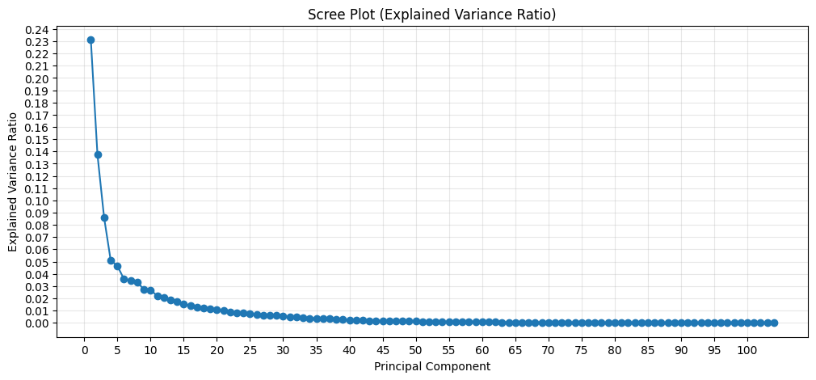

```python
plt.figure(figsize=(12, 5))
plt.plot(range(1, len(explained_var_ratio2) + 1), explained_var_ratio2, marker="o")
plt.title("Scree Plot (Explained Variance Ratio)")
plt.xlabel("Principal Component")
plt.xticks(range(0, len(explained_var_ratio2), 5))
plt.ylabel("Explained Variance Ratio")
plt.yticks(np.arange(0, max(explained_var_ratio2) + 0.01, 0.01))
plt.grid(alpha=0.3)
plt.show()
```

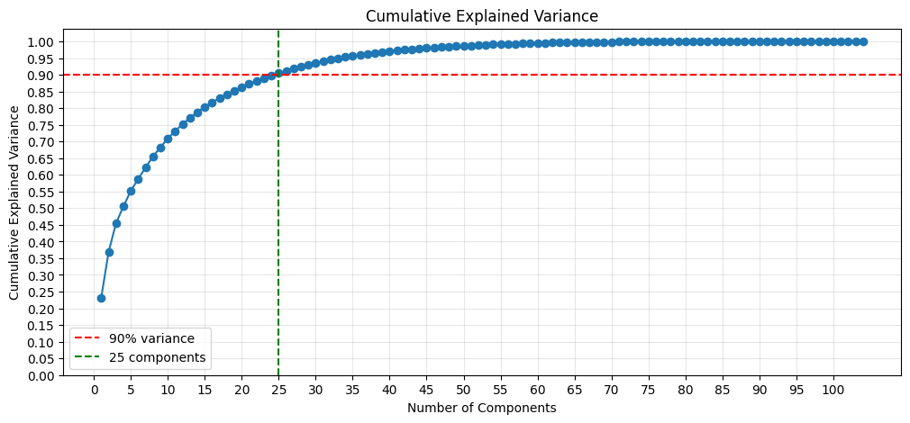

```python
plt.figure(figsize=(12, 5))
plt.plot(range(1, len(cum_explained2) + 1), cum_explained2, marker="o")
plt.axhline(0.90, color="red", linestyle="--", label="90% variance")
plt.axvline(n_components_90, color="green", linestyle="--", label=f"{n_components_90} components")
plt.title("Cumulative Explained Variance")
plt.xlabel("Number of Components")
plt.xticks(range(0, len(cum_explained2) + 1, 5))
plt.ylabel("Cumulative Explained Variance")
plt.yticks(np.arange(0, 1.01, 0.05))
plt.legend()
plt.grid(alpha=0.3)
plt.show()
```

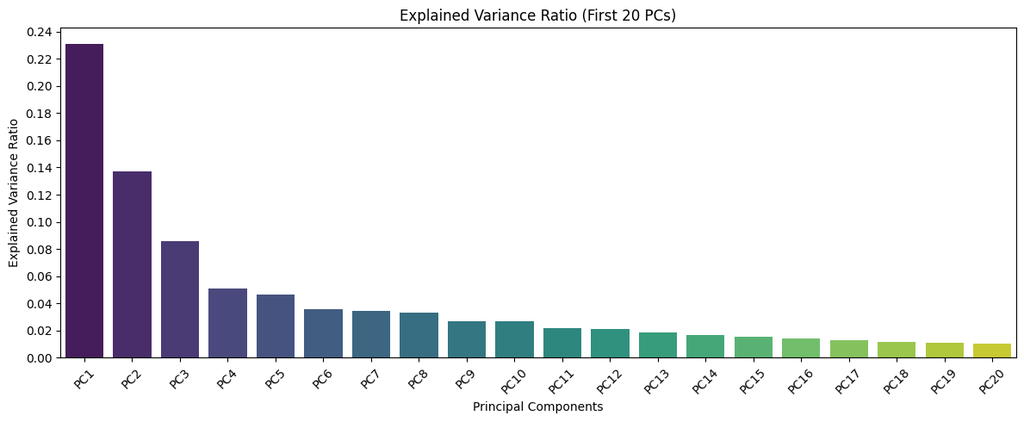

```python
k = min(20, len(explained_var_ratio2))
plt.figure(figsize=(12, 5))
sns.barplot(x=[f"PC{i}" for i in range(1, k + 1)], y=explained_var_ratio2[:k], palette="viridis")
plt.title("Explained Variance Ratio (First 20 PCs)")
plt.xlabel("Principal Components")
plt.ylabel("Explained Variance Ratio")
plt.xticks(rotation=45)
plt.yticks(np.arange(0, max(explained_var_ratio2[:k]) + 0.02, 0.02))
plt.tight_layout()
plt.show()
```

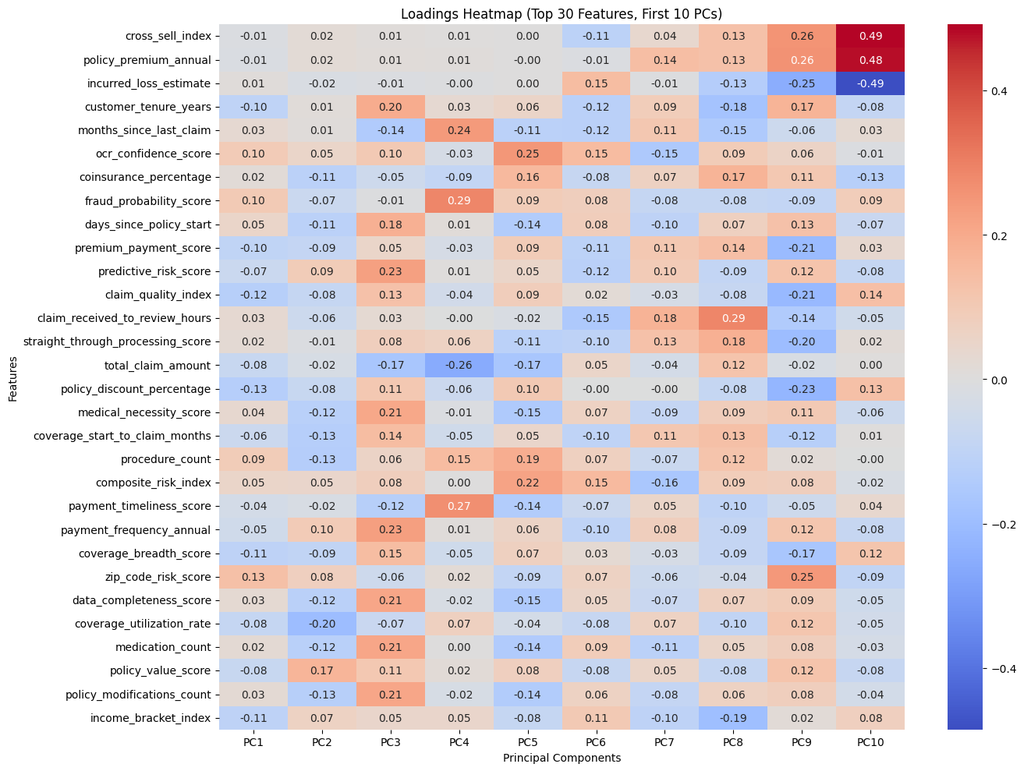

```python
n_heat_pcs = min(10, n_components_90)
feature_importance = loadings.iloc[:, :n_heat_pcs].abs().sum(axis=1).sort_values(ascending=False)
top_features_heat = feature_importance.head(30).index

plt.figure(figsize=(14, 10))
sns.heatmap(
    loadings.loc[top_features_heat, pc_cols[:n_heat_pcs]],
    cmap="coolwarm",
    annot=True,
    fmt=".2f",
    center=0
)
plt.title(f"Loadings Heatmap (Top 30 Features, First {n_heat_pcs} PCs)")
plt.xlabel("Principal Components")
plt.ylabel("Features")
plt.tight_layout()
plt.show()
```

We notice that for almost each PC that the contribitions of are Distributed across the features.there is not a dominant feature except the PC10 that has 3 dominant features

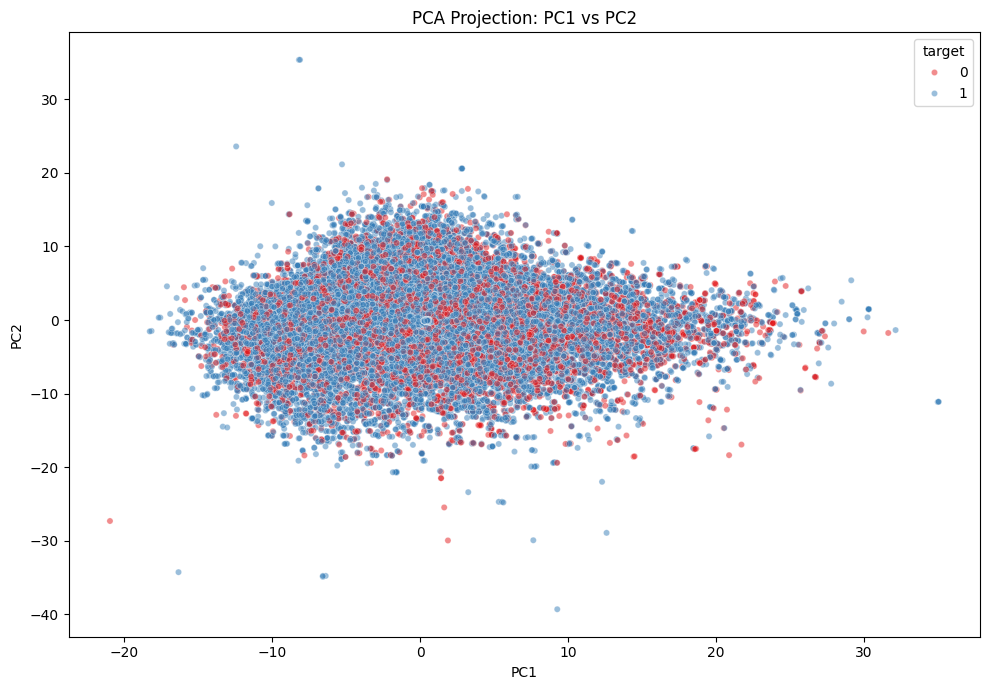

```python
plot_df = data_pca.copy()
plt.figure(figsize=(10, 7))
if "target" in plot_df.columns:
    sns.scatterplot(data=plot_df, x="PC1", y="PC2", hue="target", alpha=0.5, s=20, palette="Set1")
else:
    sns.scatterplot(data=plot_df, x="PC1", y="PC2", alpha=0.5, s=20)
plt.title("PCA Projection: PC1 vs PC2")
plt.tight_layout()
plt.show()
```

The target classes points are Overlapping in each other, the same of the outliers, that shows that these components does not have much predictive power.

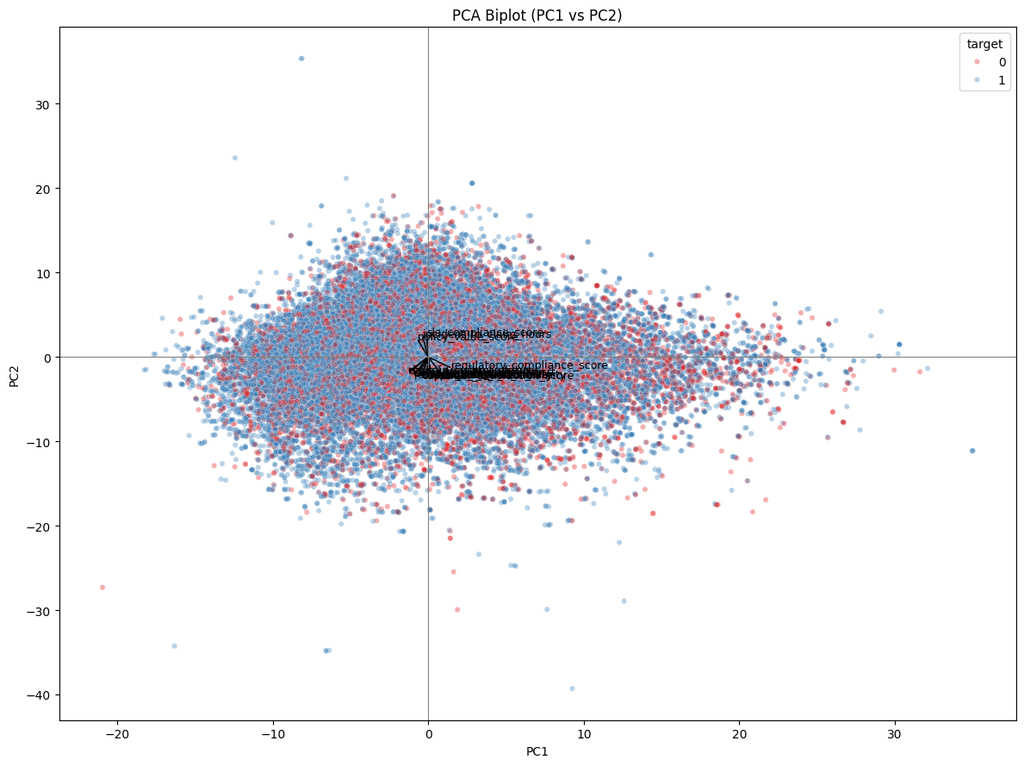

```python
scores_2d = X_pca_90[:, :2]
loadings_2d = pca_90.components_[:2, :].T  # features x 2

arrow_strength = np.sqrt((loadings_2d ** 2).sum(axis=1))
top_arrow_idx = np.argsort(arrow_strength)[-15:]  # top 15 arrows

plt.figure(figsize=(12, 9))
sns.scatterplot(
    x=scores_2d[:, 0], y=scores_2d[:, 1],
    hue=data_pca["target"], alpha=0.35, s=20, palette="Set1", legend=True
)

scale_x = (scores_2d[:, 0].max() - scores_2d[:, 0].min()) * 0.15
scale_y = (scores_2d[:, 1].max() - scores_2d[:, 1].min()) * 0.15

for i in top_arrow_idx:
    x_vec = loadings_2d[i, 0] * scale_x
    y_vec = loadings_2d[i, 1] * scale_y
    plt.arrow(0, 0, x_vec, y_vec, color="black", alpha=0.8, head_width=0.05)
    plt.text(x_vec * 1.08, y_vec * 1.08, numeric_cols[i], fontsize=9)

plt.axhline(0, color="gray", linewidth=0.8)
plt.axvline(0, color="gray", linewidth=0.8)
plt.xlabel("PC1")
plt.ylabel("PC2")
plt.title("PCA Biplot (PC1 vs PC2)")
plt.tight_layout()
plt.show()
```

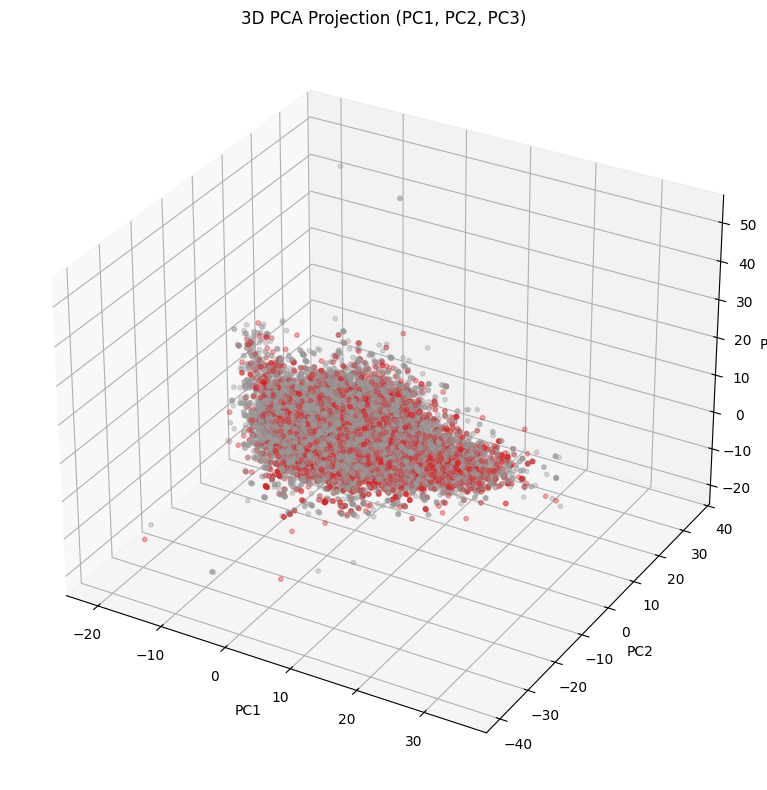

```python
fig = plt.figure(figsize=(10, 8))
ax = fig.add_subplot(111, projection="3d")
if "target" in data_pca.columns:
    target_codes = pd.Categorical(data_pca["target"]).codes
    sc = ax.scatter(
        data_pca["PC1"], data_pca["PC2"], data_pca["PC3"],
        c=target_codes, cmap="Set1", alpha=0.35, s=10
    )
else:
    ax.scatter(data_pca["PC1"], data_pca["PC2"], data_pca["PC3"], alpha=0.35, s=10)
ax.set_title("3D PCA Projection (PC1, PC2, PC3)")
ax.set_xlabel("PC1")
ax.set_ylabel("PC2")
ax.set_zlabel("PC3")
plt.tight_layout()
plt.show()
```

the same observation for the 2D plot.

## UMAP

From the PCA Analysis we concluded that The data does not separate linearly (or even mildly nonlinearly) w.r.t. the target so we apply UMAP but on data after PCA

```python
data_pca.columns
```

```
Index(['PC1', 'PC2', 'PC3', 'PC4', 'PC5', 'PC6', 'PC7', 'PC8', 'PC9', 'PC10',
       'PC11', 'PC12', 'PC13', 'PC14', 'PC15', 'PC16', 'PC17', 'PC18', 'PC19',
       'PC20', 'PC21', 'PC22', 'PC23', 'PC24', 'PC25', 'target'],
      dtype='str')
```

```python
X_umap = data_pca.drop(columns=["target"], errors="ignore").copy()
y_umap = data_pca["target"].copy()

print("UMAP input shape:", X_umap.shape)
print("\nTarget distribution:")
display(y_umap.value_counts(dropna=False).to_frame("count").assign(pct=lambda d: d["count"] / len(y_umap) * 100))
```

```
UMAP input shape: (109537, 25)

Target distribution:
```

| target | count | pct |
| --- | --- | --- |
| 1 | 83130 | 75.892164 |
| 0 | 26407 | 24.107836 |

```python
umap_2d = umap.UMAP(
    n_neighbors=30,
    min_dist=0.05,
    n_components=2,
    metric="euclidean",
    random_state=42,
    low_memory=True,
    n_epochs=200,
    n_jobs=-1
)
embedding_2d = umap_2d.fit_transform(X_umap)

umap_2d_df = pd.DataFrame(embedding_2d, columns=["UMAP1", "UMAP2"], index=data_pca.index)
umap_2d_df["target"] = y_umap.values

sil_2d = silhouette_score(embedding_2d, y_umap)
print("\n=== 2D UMAP Summary ===")
print("Embedding shape:", embedding_2d.shape)
print(f"Silhouette score: {sil_2d:.4f}" if not np.isnan(sil_2d) else "Silhouette score: NA")

display(umap_2d_df.head())
display(pd.DataFrame({
    "metric": ["silhouette"],
    "value": [sil_2d]
}))
```

```
=== 2D UMAP Summary ===
Embedding shape: (109537, 2)
Silhouette score: 0.0004
```

|  | UMAP1 | UMAP2 | target |
| --- | --- | --- | --- |
| 0 | -3.552268 | 10.422455 | 1 |
| 1 | 0.116656 | -3.549241 | 1 |
| 2 | -3.387144 | 8.007833 | 1 |
| 3 | -6.551101 | 9.463568 | 1 |
| 4 | 12.728157 | 8.171824 | 1 |

|  | metric | value |
| --- | --- | --- |
| 0 | silhouette | 0.000429 |

Even after nonlinear projection (UMAP), the classes are still heavily overlapping

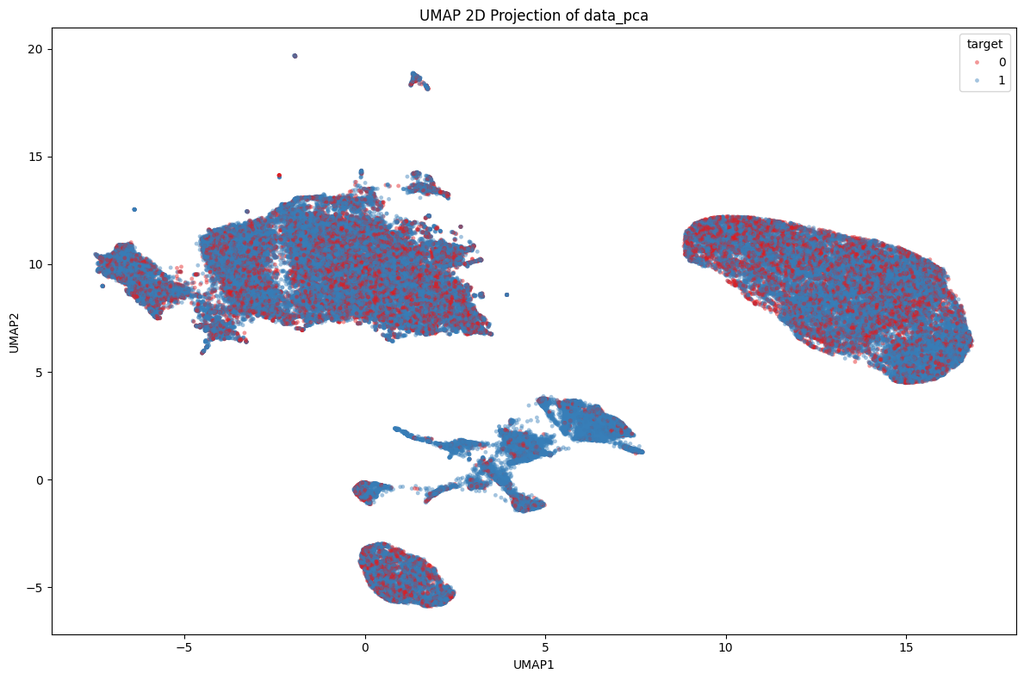

```python
plt.figure(figsize=(12, 8))
sns.scatterplot(
    data=umap_2d_df,
    x="UMAP1",
    y="UMAP2",
    hue="target",
    palette="Set1",
    s=12,
    alpha=0.45,
    linewidth=0
)
plt.legend(title="target", loc="best")
plt.title("UMAP 2D Projection of data_pca")
plt.tight_layout()
plt.show()
```

we can see a few clusters about 4 Clusters, they have a little unusually shapes and almost the same points of the target classes except for the midlle weird shape one that mostly of his points belong to the positive class

```python
umap_3d = umap.UMAP(
    n_neighbors=30,
    min_dist=0.05,
    n_components=3,
    metric="euclidean",
    random_state=42,
    low_memory=True,
    n_epochs=200,
    n_jobs=-1
)
embedding_3d = umap_3d.fit_transform(X_umap)

umap_3d_df = pd.DataFrame(embedding_3d, columns=["UMAP1", "UMAP2", "UMAP3"], index=data_pca.index)
umap_3d_df["target"] = y_umap.values

sil_3d = silhouette_score(embedding_3d, y_umap)

print("\n=== 3D UMAP Summary ===")
print("Embedding shape:", embedding_3d.shape)
print(f"Silhouette score: {sil_3d:.4f}")

display(umap_3d_df.head())
display(pd.DataFrame({
    "metric": ["silhouette"],
    "value": [sil_3d]
}))
```

```
=== 3D UMAP Summary ===
Embedding shape: (109537, 3)
Silhouette score: 0.0079
```

|  | UMAP1 | UMAP2 | UMAP3 | target |
| --- | --- | --- | --- | --- |
| 0 | -1.356821 | 10.119258 | 2.177392 | 1 |
| 1 | 1.236562 | -2.553229 | 5.975742 | 1 |
| 2 | -1.072217 | 8.045613 | 2.639787 | 1 |
| 3 | -2.354322 | 8.170403 | 0.164038 | 1 |
| 4 | 12.103870 | 7.341076 | 6.404824 | 1 |

|  | metric | value |
| --- | --- | --- |
| 0 | silhouette | 0.007929 |

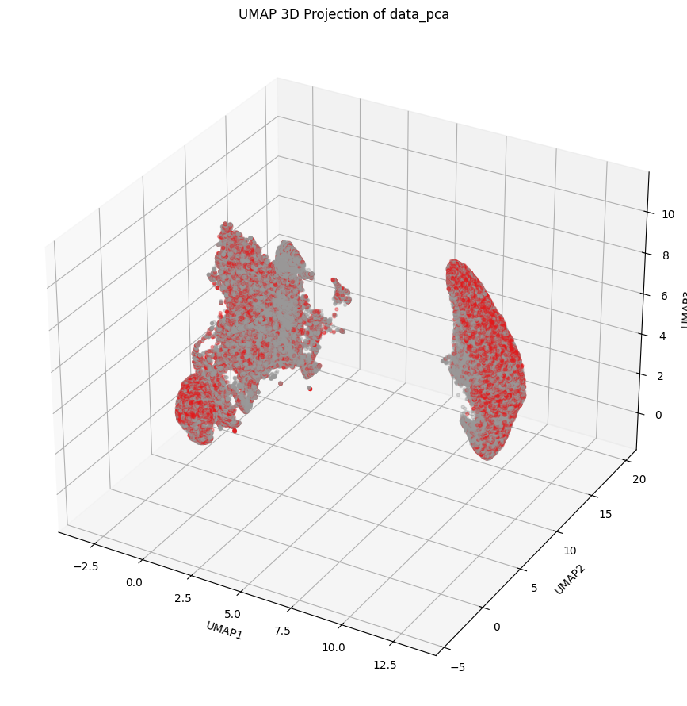

```python
fig = plt.figure(figsize=(12, 9))
ax = fig.add_subplot(111, projection="3d")
target_codes = pd.Categorical(y_umap).codes
sc = ax.scatter(
    umap_3d_df["UMAP1"], umap_3d_df["UMAP2"], umap_3d_df["UMAP3"],
    c=target_codes, cmap="Set1", s=8, alpha=0.35
)
ax.set_title("UMAP 3D Projection of data_pca")
ax.set_xlabel("UMAP1")
ax.set_ylabel("UMAP2")
ax.set_zlabel("UMAP3")
plt.tight_layout()
plt.show()
```

```python
fig = px.scatter_3d(
    umap_3d_df,
    x="UMAP1",
    y="UMAP2",
    z="UMAP3",
    color=y_umap.astype(str),
    opacity=0.6,
    title="Interactive 3D UMAP Projection"
)

fig.update_traces(marker=dict(size=3))
fig.show()
```

[output not shown]

now we will try multiple parameters of umap to see if theses shapes would keep the same

```python
sample_n = 20000
sss = StratifiedShuffleSplit(n_splits=1, train_size=sample_n, random_state=42)
sample_idx, _ = next(sss.split(X_umap, y_umap))

X_sample = X_umap.iloc[sample_idx]
y_sample = y_umap.iloc[sample_idx]

param_grid = [
    (15, 0.00),
    (15, 0.10),
    (30, 0.00),
    (30, 0.10),
    (50, 0.00),
    (50, 0.10),
]

results = []
embeddings = []

for n_neighbors, min_dist in param_grid:
    reducer = umap.UMAP(
        n_neighbors=n_neighbors,
        min_dist=min_dist,
        n_components=2,
        metric="euclidean",
        random_state=42,
        low_memory=True,
        n_epochs=150,
        n_jobs=-1
    )
    emb = reducer.fit_transform(X_sample)
    embeddings.append(((n_neighbors, min_dist), emb))
    sil = silhouette_score(emb, y_sample)
    results.append({
        "n_neighbors": n_neighbors,
        "min_dist": min_dist,
        "silhouette": sil
    })

results_df = pd.DataFrame(results).sort_values(["silhouette"], ascending=False)
print("\n=== UMAP Parameter Comparison (sample) ===")
display(results_df)
```

```
=== UMAP Parameter Comparison (sample) ===
```

|  | n_neighbors | min_dist | silhouette |
| --- | --- | --- | --- |
| 4 | 50 | 0.0 | 0.013187 |
| 5 | 50 | 0.1 | 0.011812 |
| 3 | 30 | 0.1 | 0.008725 |
| 2 | 30 | 0.0 | 0.007771 |
| 1 | 15 | 0.1 | 0.003799 |
| 0 | 15 | 0.0 | 0.003305 |

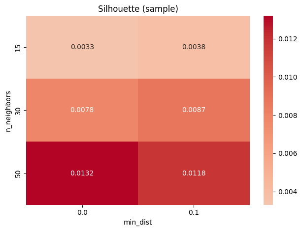

```python
pivot_sil = results_df.pivot(index="n_neighbors", columns="min_dist", values="silhouette")

sns.heatmap(pivot_sil, annot=True, fmt=".4f", cmap="coolwarm", center=0)
plt.title("Silhouette (sample)")
plt.xlabel("min_dist")
plt.ylabel("n_neighbors")
plt.tight_layout()
plt.show()
```

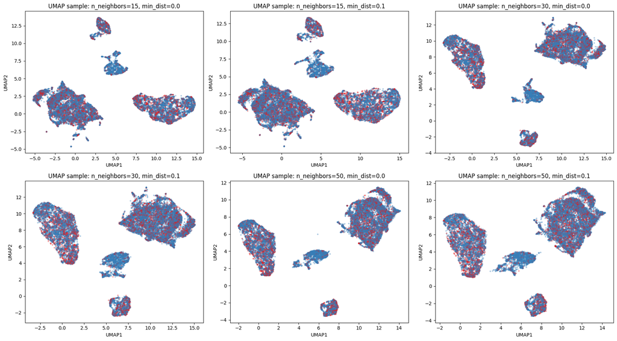

```python
fig, axes = plt.subplots(2, 3, figsize=(18, 10))
axes = axes.flatten()

for ax, ((n_neighbors, min_dist), emb) in zip(axes, embeddings):
    sns.scatterplot(
        x=emb[:, 0],
        y=emb[:, 1],
        hue=y_sample.values,
        palette="Set1",
        s=10,
        alpha=0.4,
        linewidth=0,
        ax=ax,
        legend=False
    )
    ax.set_title(f"UMAP sample: n_neighbors={n_neighbors}, min_dist={min_dist}")
    ax.set_xlabel("UMAP1")
    ax.set_ylabel("UMAP2")

plt.tight_layout()
plt.show()
```

```python
summary_df = pd.DataFrame({
    "embedding": ["UMAP_2D_full", "UMAP_3D_full"],
    "samples": [len(embedding_2d), len(embedding_3d)],
    "silhouette": [sil_2d, sil_3d]
})
print("\n=== Final Summary ===")
display(summary_df)
```

```
=== Final Summary ===
```

|  | embedding | samples | silhouette |
| --- | --- | --- | --- |
| 0 | UMAP_2D_full | 109537 | 0.000429 |
| 1 | UMAP_3D_full | 109537 | 0.007929 |

# Clustering

Wel will start with KMeans++ as a baseline

## KMeans++

```python
def sampled_silhouette(X, labels, sample_size=10000, random_state=42):
    rng = np.random.default_rng(random_state)
    idx = rng.choice(len(X), size=min(sample_size, len(X)), replace=False)
    return silhouette_score(X[idx], labels[idx])
```

```python
def evaluate_kmeans_full(X, k_range=range(2, 11), sample_size=10000):
    results = []

    for k in k_range:
        kmeans = KMeans(
            n_clusters=k,
            init="k-means++",
            n_init=10,
            random_state=42
        )

        labels = kmeans.fit_predict(X)

        inertia = kmeans.inertia_
        db_score = davies_bouldin_score(X, labels)

        sil = sampled_silhouette(X, labels, sample_size=sample_size)

        results.append({
            "k": k,
            "inertia": inertia,
            "davies_bouldin": db_score,
            "silhouette_sampled": sil
        })

        print(f"k={k} done")

    return pd.DataFrame(results)
```

```python
X_pca = data_pca.values

results_pca = evaluate_kmeans_full(X_pca)
display(results_pca)
```

```
k=2 done
k=3 done
k=4 done
k=5 done
k=6 done
k=7 done
k=8 done
k=9 done
k=10 done
```

|  | k | inertia | davies_bouldin | silhouette_sampled |
| --- | --- | --- | --- | --- |
| 0 | 2 | 8.956809e+06 | 1.716244 | 0.348245 |
| 1 | 3 | 7.934586e+06 | 1.882178 | 0.278080 |
| 2 | 4 | 7.333711e+06 | 1.801611 | 0.261596 |
| 3 | 5 | 6.888240e+06 | 1.772740 | 0.270059 |
| 4 | 6 | 6.595630e+06 | 1.839062 | 0.252266 |
| 5 | 7 | 6.347183e+06 | 1.849904 | 0.254890 |
| 6 | 8 | 6.162031e+06 | 1.909427 | 0.250201 |
| 7 | 9 | 5.992837e+06 | 1.861546 | 0.151559 |
| 8 | 10 | 5.837372e+06 | 1.837495 | 0.156851 |

```python
X_umap2d = umap_2d_df.values

results_umap2d = evaluate_kmeans_full(X_umap2d)
display(results_umap2d)
```

```
k=2 done
k=3 done
k=4 done
k=5 done
k=6 done
k=7 done
k=8 done
k=9 done
k=10 done
```

|  | k | inertia | davies_bouldin | silhouette_sampled |
| --- | --- | --- | --- | --- |
| 0 | 2 | 3.029512e+06 | 0.587063 | 0.572358 |
| 1 | 3 | 1.170484e+06 | 0.523502 | 0.664785 |
| 2 | 4 | 8.416346e+05 | 0.684912 | 0.533642 |
| 3 | 5 | 6.551957e+05 | 0.660041 | 0.524589 |
| 4 | 6 | 5.240693e+05 | 0.753258 | 0.462759 |
| 5 | 7 | 4.156662e+05 | 0.785612 | 0.449993 |
| 6 | 8 | 3.693693e+05 | 0.782998 | 0.439125 |
| 7 | 9 | 3.329818e+05 | 0.815503 | 0.423084 |
| 8 | 10 | 2.980115e+05 | 0.839742 | 0.413350 |

```python
X_umap3d = umap_3d_df.values

results_umap3d = evaluate_kmeans_full(X_umap3d)
display(results_umap3d)
```

```
k=2 done
k=3 done
k=4 done
k=5 done
k=6 done
k=7 done
k=8 done
k=9 done
k=10 done
```

|  | k | inertia | davies_bouldin | silhouette_sampled |
| --- | --- | --- | --- | --- |
| 0 | 2 | 2.448702e+06 | 0.840305 | 0.555573 |
| 1 | 3 | 1.005940e+06 | 0.591820 | 0.662283 |
| 2 | 4 | 7.743109e+05 | 0.782673 | 0.507594 |
| 3 | 5 | 5.681354e+05 | 0.701134 | 0.510305 |
| 4 | 6 | 4.658212e+05 | 0.791920 | 0.444472 |
| 5 | 7 | 3.776679e+05 | 0.814057 | 0.439023 |
| 6 | 8 | 3.411222e+05 | 0.841913 | 0.423446 |
| 7 | 9 | 3.042958e+05 | 0.765204 | 0.428678 |
| 8 | 10 | 2.760866e+05 | 0.808730 | 0.409491 |

```python
def plot_kmeans_metrics(results_df, title):
    k = results_df["k"]

    fig, ax = plt.subplots(1, 3, figsize=(18, 4))

    # Elbow
    ax[0].plot(k, results_df["inertia"], marker="o")
    ax[0].set_title(f"{title} - Elbow")
    ax[0].set_xlabel("k")
    ax[0].set_ylabel("Inertia")

    # Silhouette
    ax[1].plot(k, results_df["silhouette_sampled"], marker="o")
    ax[1].set_title(f"{title} - Silhouette (sampled)")
    ax[1].set_xlabel("k")
    ax[1].set_ylabel("Score")

    # Davies-Bouldin
    ax[2].plot(k, results_df["davies_bouldin"], marker="o")
    ax[2].set_title(f"{title} - Davies-Bouldin")
    ax[2].set_xlabel("k")
    ax[2].set_ylabel("Score (lower better)")

    plt.tight_layout()
    plt.show()
```

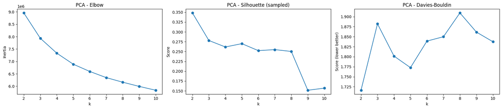

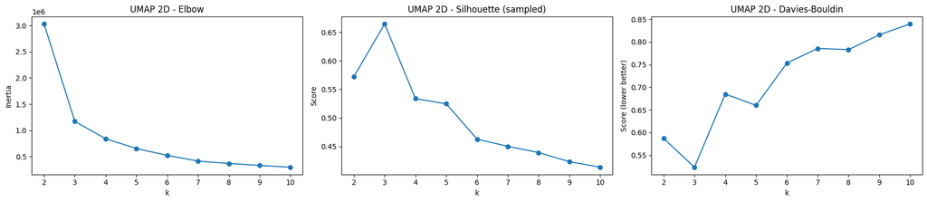

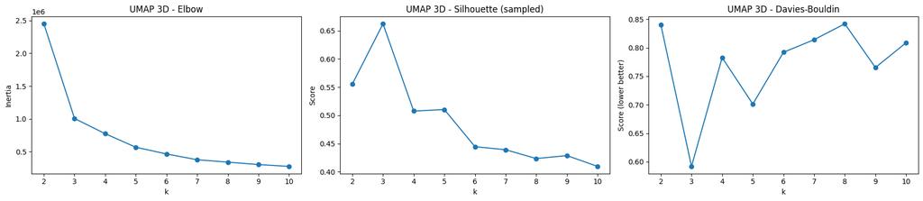

```python
plot_kmeans_metrics(results_pca, "PCA")
plot_kmeans_metrics(results_umap2d, "UMAP 2D")
plot_kmeans_metrics(results_umap3d, "UMAP 3D")
```

```python
def get_best_k(results_df):
    return results_df.loc[
        results_df["silhouette_sampled"].idxmax(), "k"
    ]
```

```python
best_k_pca = get_best_k(results_pca)
best_k_umap2d = get_best_k(results_umap2d)
best_k_umap3d = get_best_k(results_umap3d)

print(best_k_pca, best_k_umap2d, best_k_umap3d)
```

```
2 3 3
```

```python
def plot_2d_clusters(X, labels, centroids, title):
    plt.figure(figsize=(6,5))
    plt.scatter(X[:,0], X[:,1], c=labels, cmap="tab10", s=10, alpha=0.6)
    plt.scatter(centroids[:,0], centroids[:,1], c="black", s=200, marker="X")
    plt.title(title)
    plt.xlabel("Component 1")
    plt.ylabel("Component 2")
    plt.show()
```

```python
def plot_3d_clusters(X, labels, centroids, title):
    df_plot = pd.DataFrame(X, columns=["UMAP1", "UMAP2", "UMAP3"])
    df_plot["cluster"] = labels.astype(str)
    plt.figure(figsize=(6,5))

    fig = px.scatter_3d(
        df_plot,
        x="UMAP1",
        y="UMAP2",
        z="UMAP3",
        color="cluster",
        title=title,
        opacity=0.6,
    )

    fig.add_scatter3d(
        x=centroids[:, 0],
        y=centroids[:, 1],
        z=centroids[:, 2],
        mode="markers",
        marker=dict(size=6, color="black"),
        name="centroids"
    )

    fig.show()
```

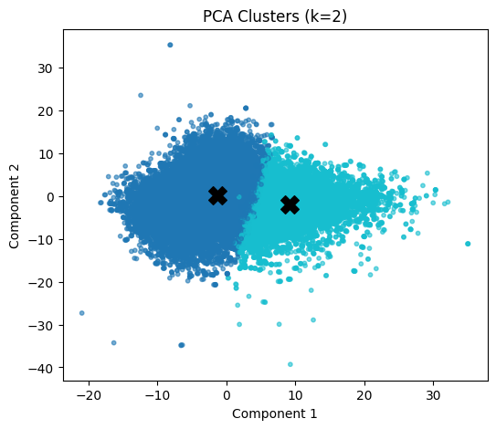

```python
kmeans = KMeans(n_clusters=best_k_pca, init="k-means++", n_init=10, random_state=42)
labels = kmeans.fit_predict(X_pca)

plot_2d_clusters(
    X_pca[:, :2],
    labels,
    kmeans.cluster_centers_[:, :2],
    f"PCA Clusters (k={best_k_pca})"
)
```

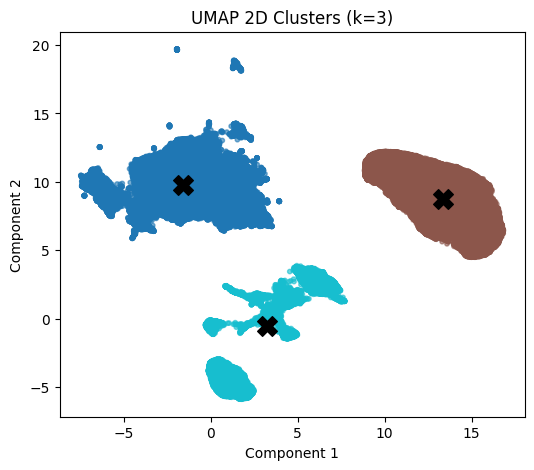

```python
kmeans = KMeans(n_clusters=best_k_umap2d, init="k-means++", n_init=10, random_state=42)
labels = kmeans.fit_predict(X_umap2d)

df = data.copy()
df["cluster"] = labels

plot_2d_clusters(
    X_umap2d[:, :2],
    labels,
    kmeans.cluster_centers_[:, :2],
    f"UMAP 2D Clusters (k={best_k_umap2d})"
)
```

```python
num_cols = df.select_dtypes(include=np.number).columns.drop("cluster")

cluster_profile = df.groupby("cluster")[num_cols].agg(["mean", "std", "median"])
display(cluster_profile)
```

| cluster | claim_amount_ratio mean | claim_amount_ratio std | claim_amount_ratio median | risk_score mean | risk_score std | risk_score median | deductible_ratio mean | deductible_ratio std | deductible_ratio median | premium_payment_score mean | ... | claim_quality_index median | customer_value_score mean | customer_value_score std | customer_value_score median | regulatory_compliance_score mean | regulatory_compliance_score std | regulatory_compliance_score median | final_decision_confidence mean | final_decision_confidence std | final_decision_confidence median |
| --- | --- | --- | --- | --- | --- | --- | --- | --- | --- | --- | --- | --- | --- | --- | --- | --- | --- | --- | --- | --- | --- |
| 0 | 1.634909 | 1.071989 | 1.498734 | 7.441909 | 2.935231 | 6.988888 | 4.131600 | 1.135938 | 4.170208 | 8.727607 | ... | 1.789657 | 0.314124 | 0.692801 | 0.0 | 1.930569 | 1.259596 | 1.589520 | 1.733476 | 1.122428 | 1.612904 |
| 1 | 1.704156 | 0.027963 | 1.704065 | 6.441281 | 0.070491 | 6.440571 | 3.987143 | 0.016898 | 3.987185 | 9.121863 | ... | 1.605921 | 0.000836 | 0.030089 | 0.0 | 1.785505 | 0.012035 | 1.785516 | 1.670512 | 0.026268 | 1.670417 |
| 2 | 1.699495 | 0.164100 | 1.704065 | 6.467187 | 0.391850 | 6.440571 | 3.990406 | 0.106980 | 3.987185 | 9.096582 | ... | 1.605921 | 0.794694 | 0.928193 | 1.0 | 1.783686 | 0.087433 | 1.785516 | 1.668053 | 0.168693 | 1.670417 |

3 rows × 312 columns